# HW2 Markdown

Patrick Walker

October 19, 2018

The value of a predicted by the iterations doesn’t converge to the true value but does appear to converge to the Least Squares model with increasing iterations. I do notice that the histogram for a becomes more sharply peaked as well as the fact that the true estimate is bettered centered towards the middle of the plot of chain. This effect is observed as one transitions both between 1000 iterations with 500 burnIn to 10000 iterations with 5000 burnIn, as well as between the latter and 100000 with 50000 burnIn. With higher numbers of iterations we see the values predicted by the Metropolis Hastings begin to converge to those of the standard linear distribution.

```r
compare_outcomes <- function(iterations, burnIn){

  if(burnIn > iterations){return("burnIN can't be longer than iterations")}
                            #the above line was added to prevent errors of non-finite length vectors
  source(file = "C:\\Users\\Patrick's Computer\\Documents\\GitHub\\assignment-2-cardinalbraxiatel\\HW2 part 4.R") #Opens file of Metropolis function

  a_vals <- matrix(nrow = 10, ncol = 2) #a blank matrix in which to put the mean and sd of a

  for(i in 1:10){ #for loop for each of the iterations
  a_int <- runif(1) #random number inserted for a
  b_int <- runif(1) #random number inserted for b
  sd_int <- runif(1) #random number inserted for sd

  startvalue <- c(a_int,b_int,sd_int) #feeds the above random numbers into startvalue

  chain_final = (Metropolis(iterations, burnIn )) #defines chain as the output of the Metropolis function

 #chain_final <- chain_final[-burnIn,] #I included this because I assume you don't want the burnIn

    mean_a <- mean(chain_final[,1]) #takes the mean of the first column of the chain
  std <- sd(chain_final[,1]) #takes the standard deviation of the first column of chain
  a_vals[i,1] <- mean_a #stores mean_a in ith row 1st column of a_vals
  a_vals[i,2] <- std #stores std in ith row 2nd colum of a_vals


  print(a_vals[i,]) #prints ith row of a_vals

  }



return(a_vals)
}


print("1000 iterations, 500 burnIn")
```

```
## [1] "1000 iterations, 500 burnIn"
```

```r
  a_vals2 <- compare_outcomes(1000, 500)
```

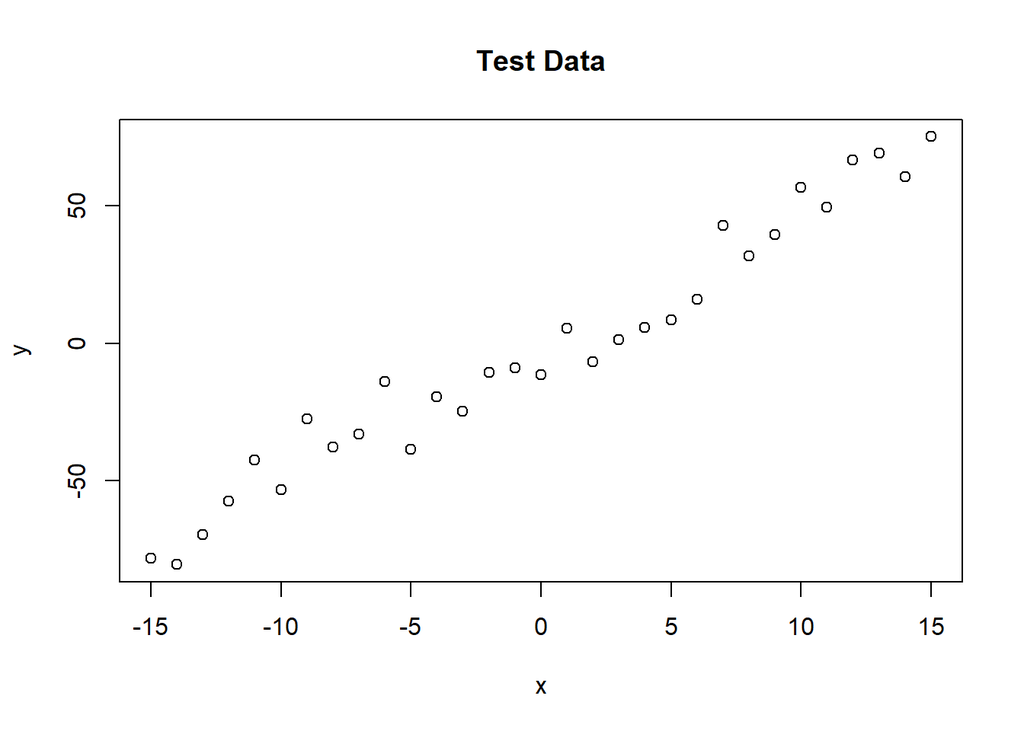

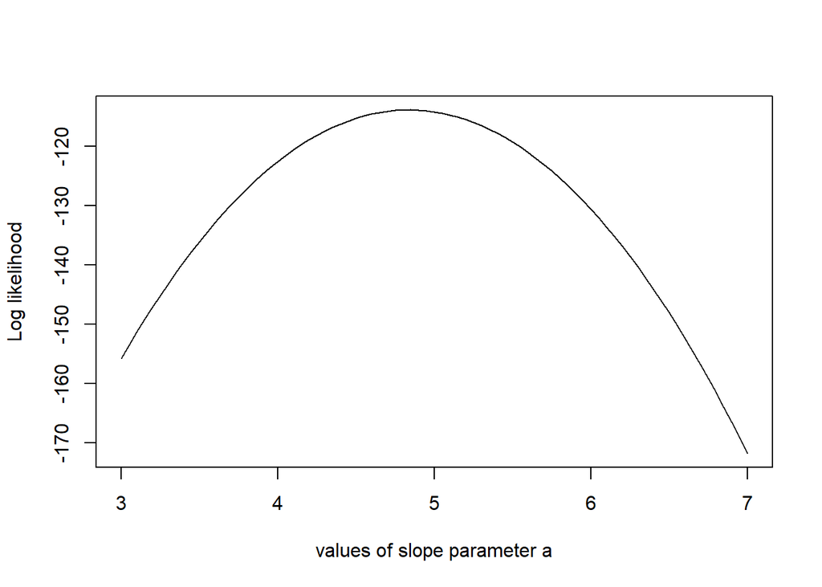

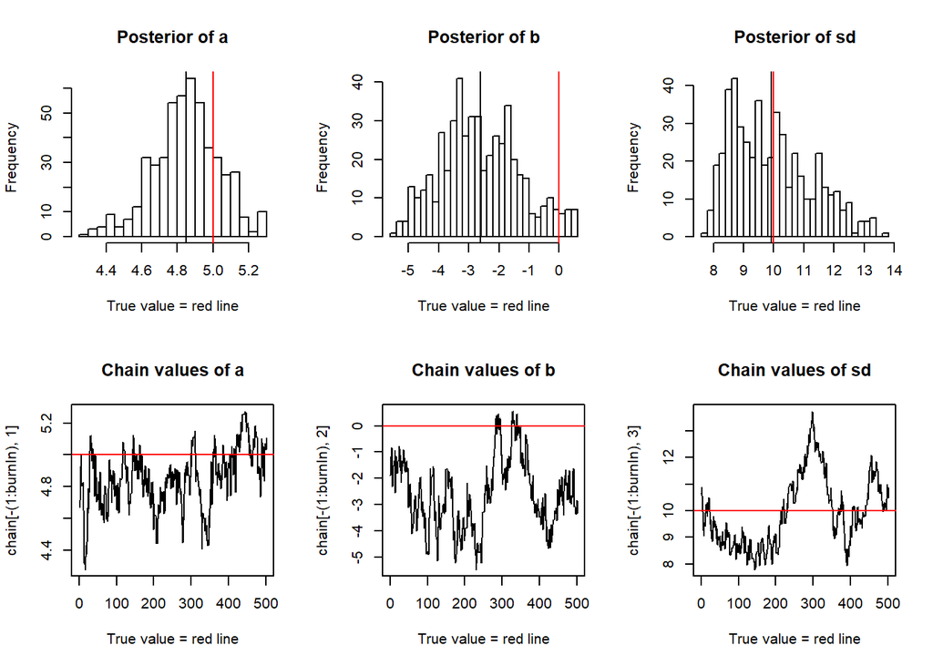

```
##
## Call:
## lm(formula = y ~ x)
##
## Residuals:
##     Min      1Q  Median      3Q     Max
## -13.572  -8.086  -1.311   4.559  18.676
##
## Coefficients:
##             Estimate Std. Error t value Pr(>|t|)
## (Intercept)  -2.8049     1.6833  -1.666    0.106
## x             4.8385     0.1882  25.709   <2e-16 ***
## ---
## Signif. codes:  0 '***' 0.001 '**' 0.01 '*' 0.05 '.' 0.1 ' ' 1
##
## Residual standard error: 9.372 on 29 degrees of freedom
## Multiple R-squared:  0.958,  Adjusted R-squared:  0.9565
## F-statistic:   661 on 1 and 29 DF,  p-value: < 2.2e-16
##
## [1] 4.8183308 0.2198947
```

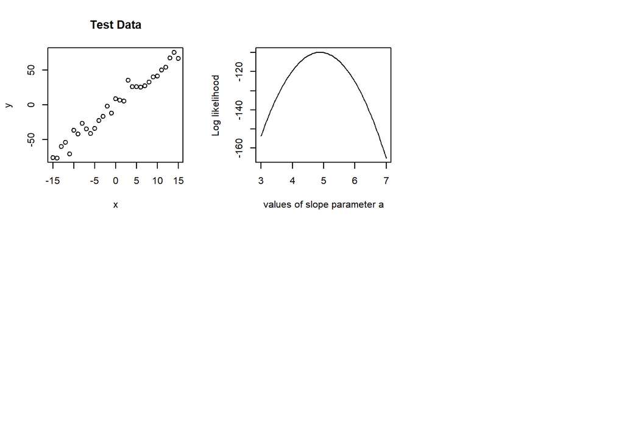

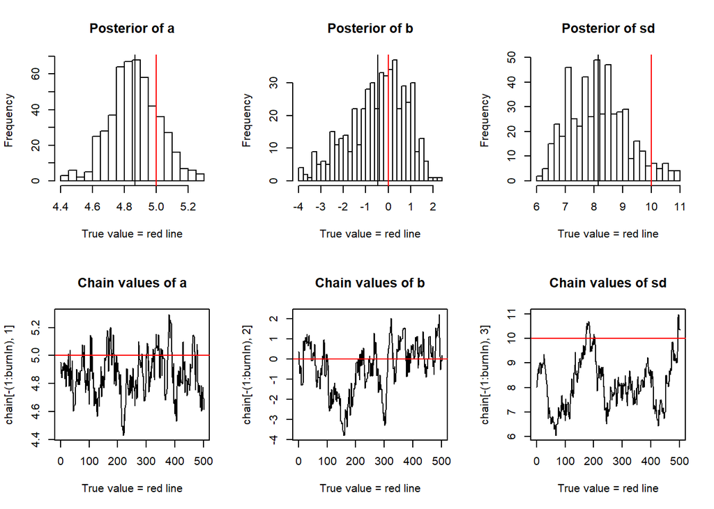

```
##
## Call:
## lm(formula = y ~ x)
##
## Residuals:
##     Min      1Q  Median      3Q     Max
## -16.491  -5.760  -2.321   5.090  21.338
##
## Coefficients:
##             Estimate Std. Error t value Pr(>|t|)
## (Intercept)  -0.5365     1.4819  -0.362     0.72
## x             4.8813     0.1657  29.462   <2e-16 ***
## ---
## Signif. codes:  0 '***' 0.001 '**' 0.01 '*' 0.05 '.' 0.1 ' ' 1
##
## Residual standard error: 8.251 on 29 degrees of freedom
## Multiple R-squared:  0.9677, Adjusted R-squared:  0.9666
## F-statistic:   868 on 1 and 29 DF,  p-value: < 2.2e-16
##
## [1] 4.8547159 0.1676861
```

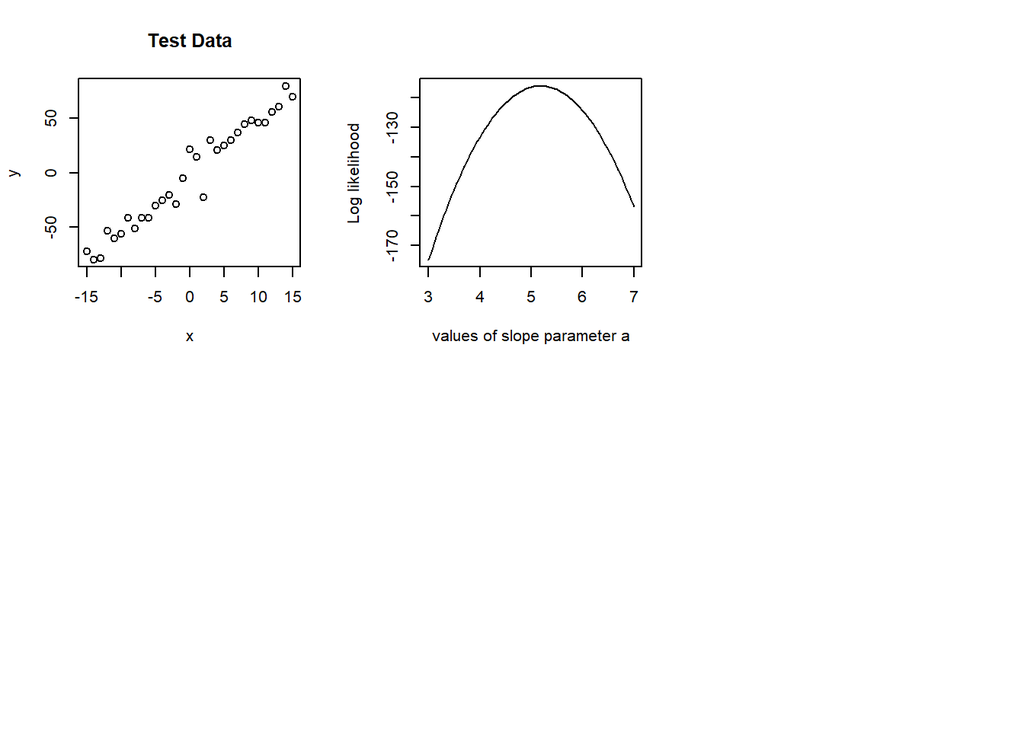

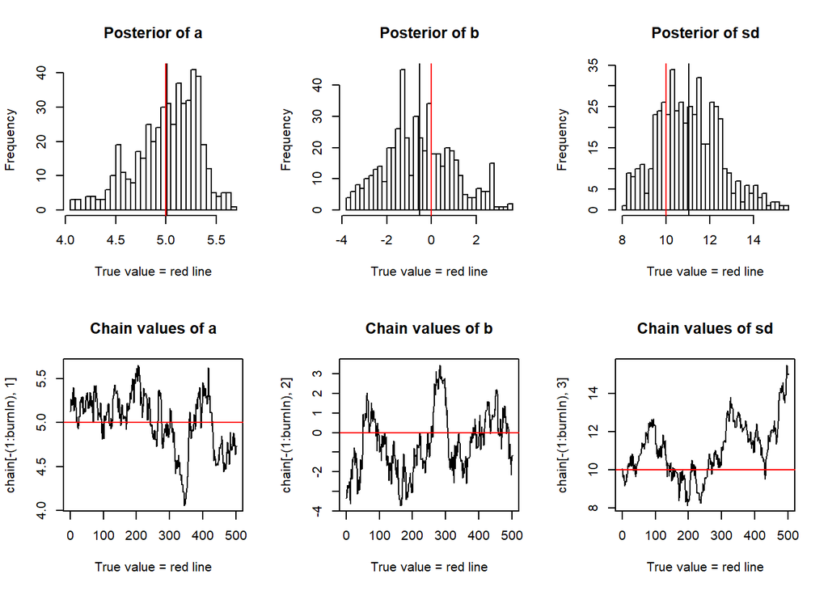

```
##
## Call:
## lm(formula = y ~ x)
##
## Residuals:
##     Min      1Q  Median      3Q     Max
## -30.589  -4.719  -1.843   4.705  24.096
##
## Coefficients:
##             Estimate Std. Error t value Pr(>|t|)
## (Intercept)  -2.5737     1.8261  -1.409    0.169
## x             5.1823     0.2042  25.383   <2e-16 ***
## ---
## Signif. codes:  0 '***' 0.001 '**' 0.01 '*' 0.05 '.' 0.1 ' ' 1
##
## Residual standard error: 10.17 on 29 degrees of freedom
## Multiple R-squared:  0.9569, Adjusted R-squared:  0.9554
## F-statistic: 644.3 on 1 and 29 DF,  p-value: < 2.2e-16
##
## [1] 5.0486684 0.2933922
```

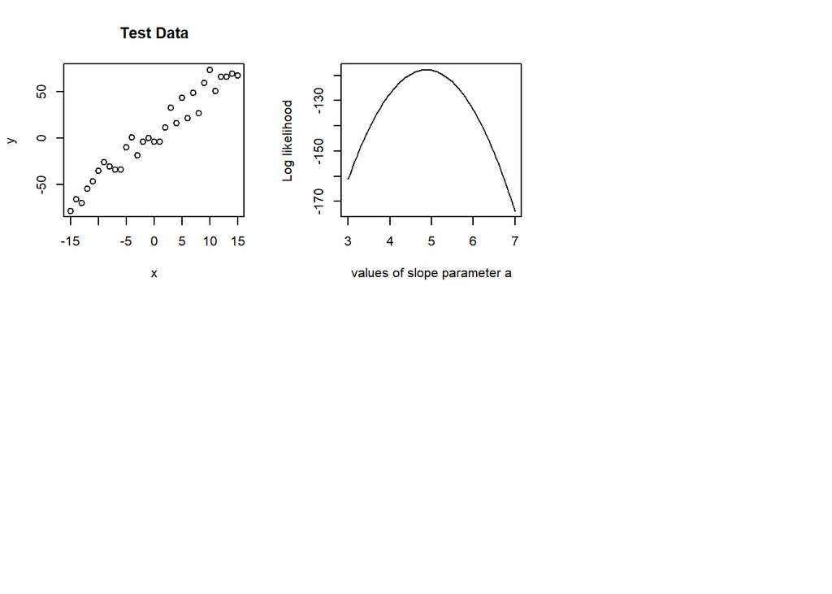

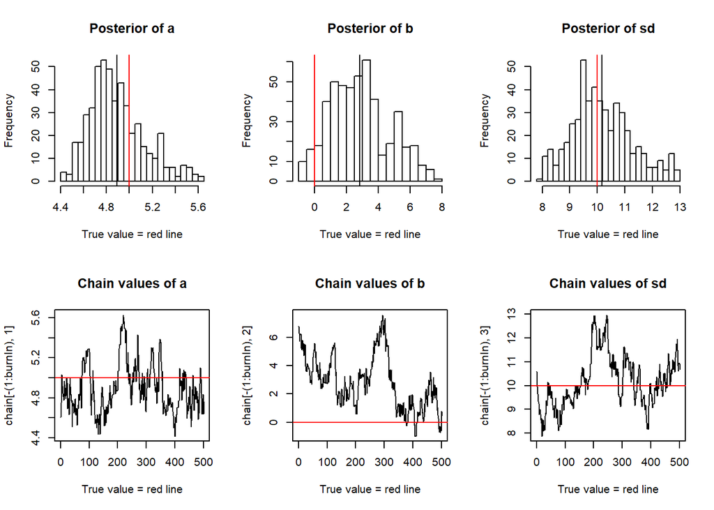

```
##
## Call:
## lm(formula = y ~ x)
##
## Residuals:
##     Min      1Q  Median      3Q     Max
## -16.489  -8.438  -1.981   9.481  20.277
##
## Coefficients:
##             Estimate Std. Error t value Pr(>|t|)
## (Intercept)   4.2644     1.8300    2.33    0.027 *
## x             4.8720     0.2046   23.81   <2e-16 ***
## ---
## Signif. codes:  0 '***' 0.001 '**' 0.01 '*' 0.05 '.' 0.1 ' ' 1
##
## Residual standard error: 10.19 on 29 degrees of freedom
## Multiple R-squared:  0.9513, Adjusted R-squared:  0.9497
## F-statistic:   567 on 1 and 29 DF,  p-value: < 2.2e-16
##
## [1] 4.8466394 0.2453697
```

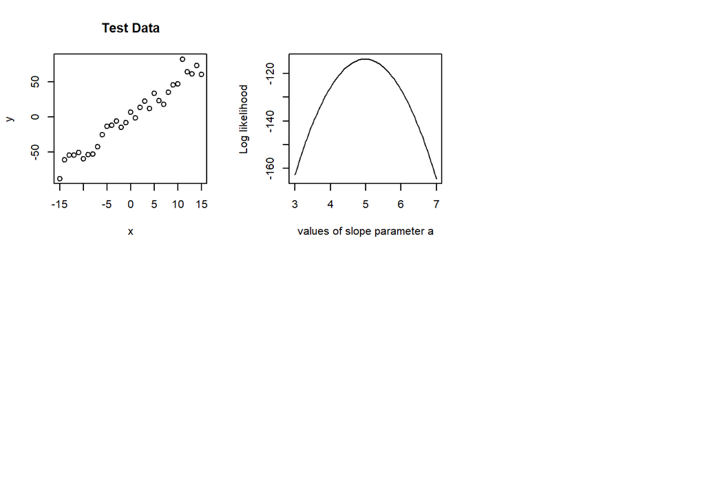

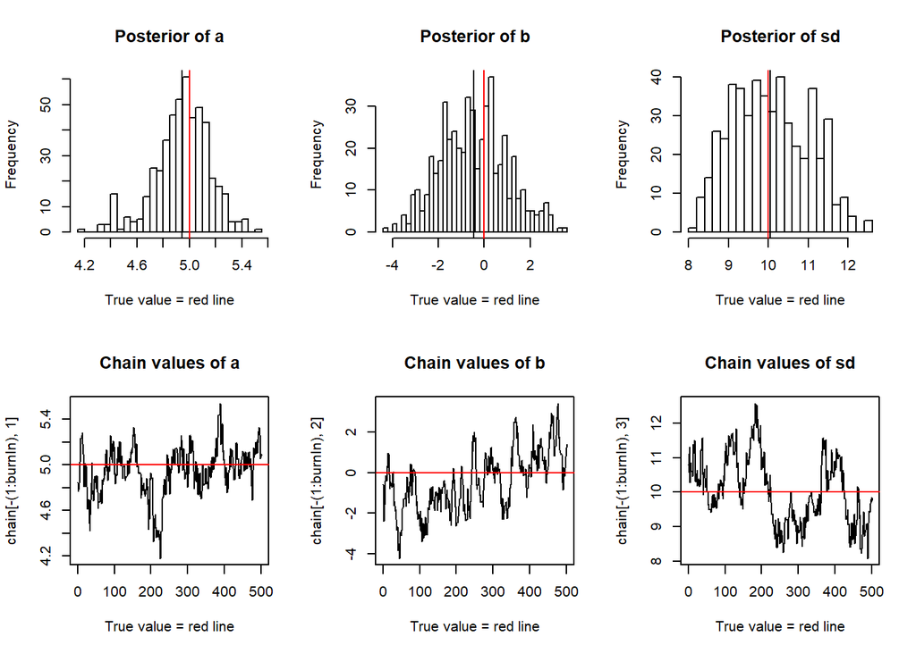

```
##
## Call:
## lm(formula = y ~ x)
##
## Residuals:
##      Min       1Q   Median       3Q      Max
## -16.6505  -7.0595   0.6744   7.0975  27.5391
##
## Coefficients:
##             Estimate Std. Error t value Pr(>|t|)
## (Intercept)  -0.1837     1.7651  -0.104    0.918
## x             4.9812     0.1973  25.241   <2e-16 ***
## ---
## Signif. codes:  0 '***' 0.001 '**' 0.01 '*' 0.05 '.' 0.1 ' ' 1
##
## Residual standard error: 9.828 on 29 degrees of freedom
## Multiple R-squared:  0.9565, Adjusted R-squared:  0.955
## F-statistic: 637.1 on 1 and 29 DF,  p-value: < 2.2e-16
##
## [1] 4.9579253 0.2366214
```

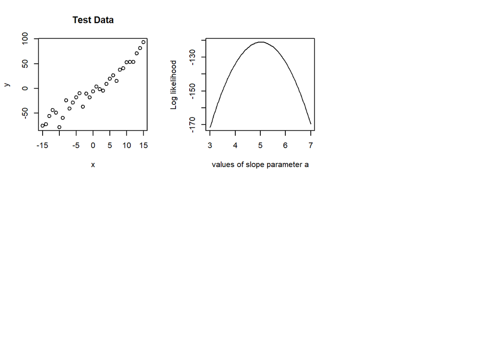

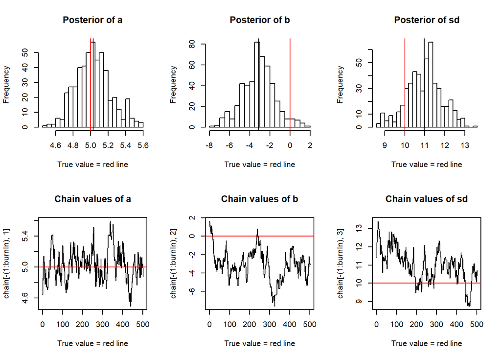

```
##
## Call:
## lm(formula = y ~ x)
##
## Residuals:
##      Min       1Q   Median       3Q      Max
## -25.7314  -6.6096   0.3745   8.6045  20.8062
##
## Coefficients:
##             Estimate Std. Error t value Pr(>|t|)
## (Intercept)   -2.433      2.120  -1.148     0.26
## x              5.019      0.237  21.175   <2e-16 ***
## ---
## Signif. codes:  0 '***' 0.001 '**' 0.01 '*' 0.05 '.' 0.1 ' ' 1
##
## Residual standard error: 11.8 on 29 degrees of freedom
## Multiple R-squared:  0.9393, Adjusted R-squared:  0.9372
## F-statistic: 448.4 on 1 and 29 DF,  p-value: < 2.2e-16
##
## [1] 5.013084 0.254948
```

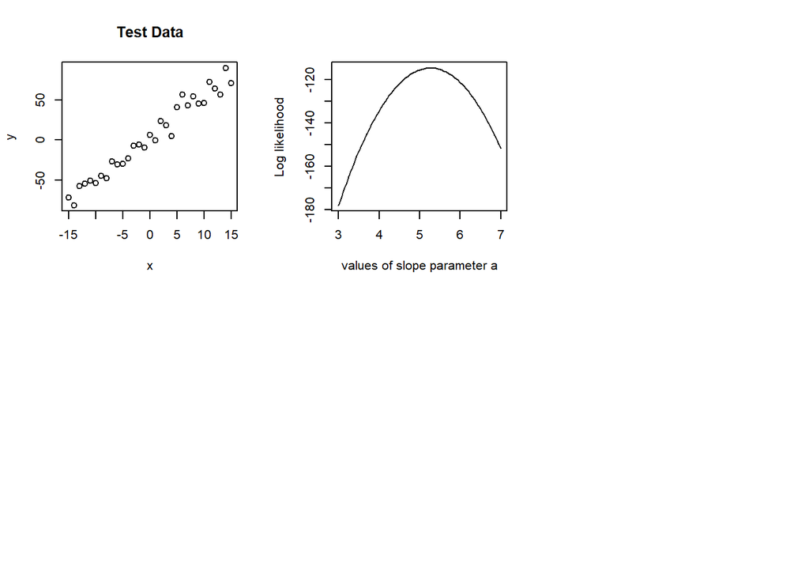

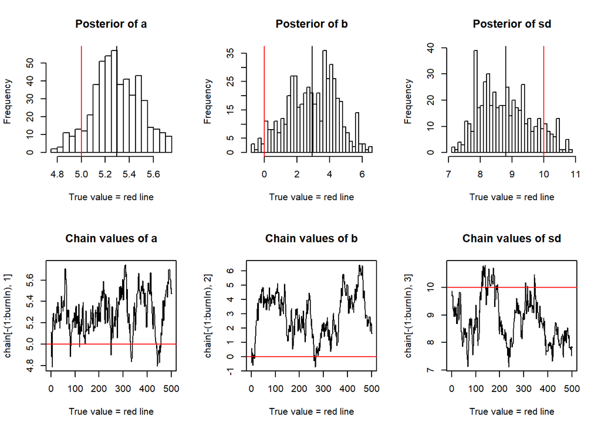

```
##
## Call:
## lm(formula = y ~ x)
##
## Residuals:
##      Min       1Q   Median       3Q      Max
## -19.4081  -6.8149  -0.7127   6.3407  21.8237
##
## Coefficients:
##             Estimate Std. Error t value Pr(>|t|)
## (Intercept)    3.211      1.699    1.89   0.0688 .
## x              5.266      0.190   27.72   <2e-16 ***
## ---
## Signif. codes:  0 '***' 0.001 '**' 0.01 '*' 0.05 '.' 0.1 ' ' 1
##
## Residual standard error: 9.46 on 29 degrees of freedom
## Multiple R-squared:  0.9636, Adjusted R-squared:  0.9624
## F-statistic: 768.4 on 1 and 29 DF,  p-value: < 2.2e-16
##
## [1] 5.2316734 0.2471382
```

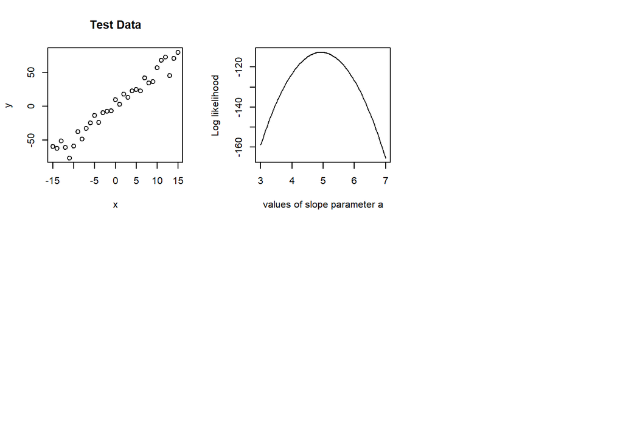

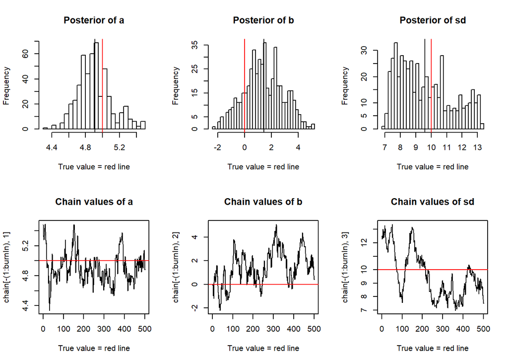

```
##
## Call:
## lm(formula = y ~ x)
##
## Residuals:
##      Min       1Q   Median       3Q      Max
## -23.9980  -4.7580   0.6876   6.0869  12.7305
##
## Coefficients:
##             Estimate Std. Error t value Pr(>|t|)
## (Intercept)   1.2603     1.6661   0.756    0.455
## x             4.9315     0.1863  26.474   <2e-16 ***
## ---
## Signif. codes:  0 '***' 0.001 '**' 0.01 '*' 0.05 '.' 0.1 ' ' 1
##
## Residual standard error: 9.277 on 29 degrees of freedom
## Multiple R-squared:  0.9603, Adjusted R-squared:  0.9589
## F-statistic: 700.9 on 1 and 29 DF,  p-value: < 2.2e-16
##
## [1] 4.8949466 0.2481482
```

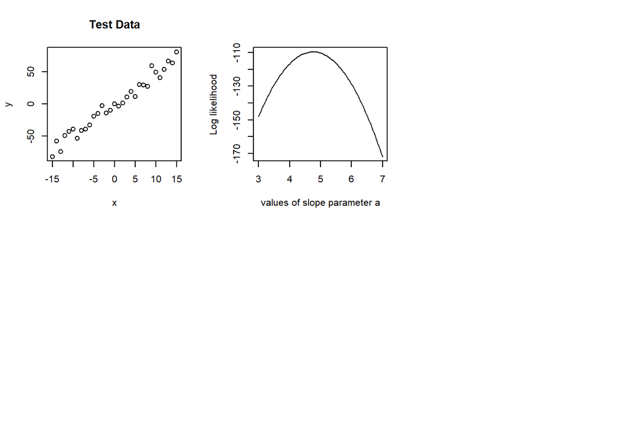

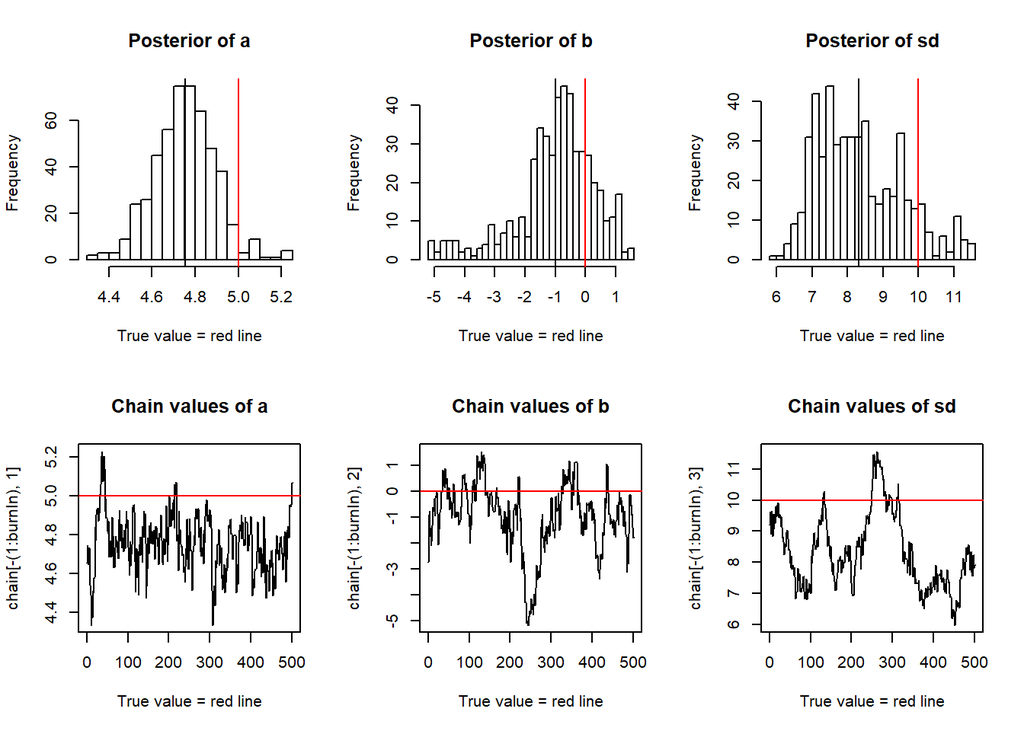

```
##
## Call:
## lm(formula = y ~ x)
##
## Residuals:
##     Min      1Q  Median      3Q     Max
## -11.333  -5.711  -2.183   5.612  17.810
##
## Coefficients:
##             Estimate Std. Error t value Pr(>|t|)
## (Intercept)  -0.9301     1.4615  -0.636     0.53
## x             4.7573     0.1634  29.114   <2e-16 ***
## ---
## Signif. codes:  0 '***' 0.001 '**' 0.01 '*' 0.05 '.' 0.1 ' ' 1
##
## Residual standard error: 8.137 on 29 degrees of freedom
## Multiple R-squared:  0.9669, Adjusted R-squared:  0.9658
## F-statistic: 847.6 on 1 and 29 DF,  p-value: < 2.2e-16
##
## [1] 4.7470610 0.1838581
```

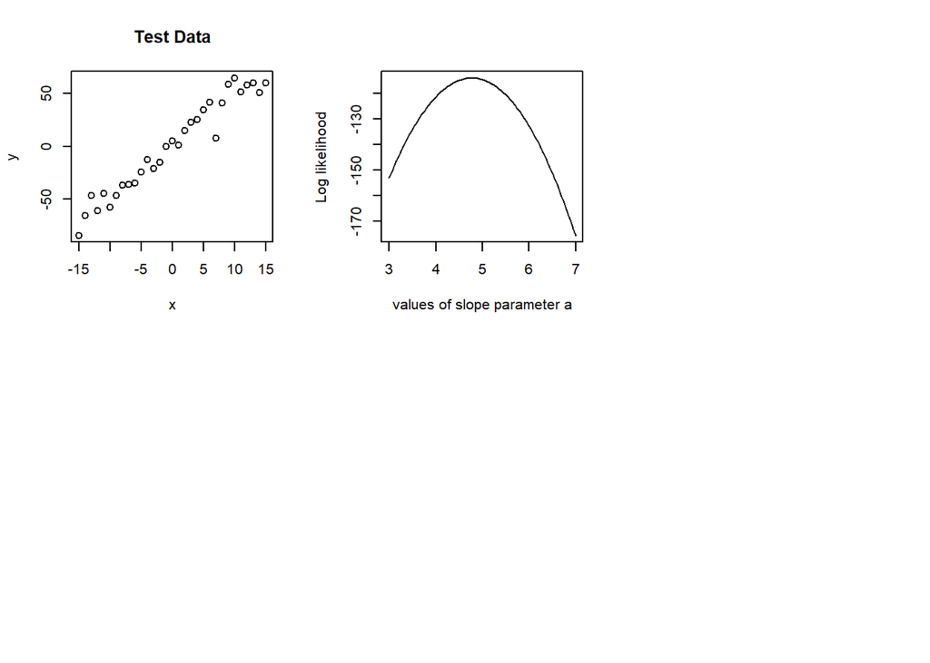

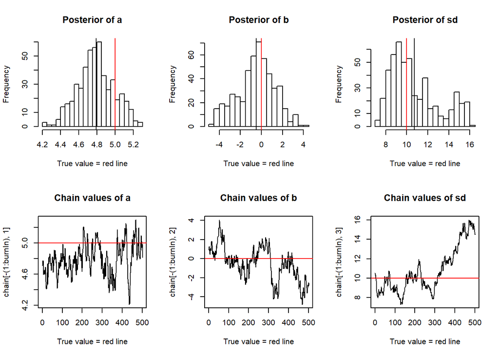

```
##
## Call:
## lm(formula = y ~ x)
##
## Residuals:
##     Min      1Q  Median      3Q     Max
## -26.271  -5.026   0.534   5.802  16.569
##
## Coefficients:
##             Estimate Std. Error t value Pr(>|t|)
## (Intercept)   0.3599     1.7736   0.203    0.841
## x             4.7713     0.1983  24.061   <2e-16 ***
## ---
## Signif. codes:  0 '***' 0.001 '**' 0.01 '*' 0.05 '.' 0.1 ' ' 1
##
## Residual standard error: 9.875 on 29 degrees of freedom
## Multiple R-squared:  0.9523, Adjusted R-squared:  0.9507
## F-statistic:   579 on 1 and 29 DF,  p-value: < 2.2e-16
##
## [1] 4.7846330 0.2321921
```

```r
   names <- c("slope 1000", "intercept 1000")
  final <- rbind(names,a_vals2)

print("*****************************************************************")
```

```
## [1] "*****************************************************************"
```

```r
print("10000 iterations, 5000 burnIn")
```

```
## [1] "10000 iterations, 5000 burnIn"
```

```r
  a_vals2 <- compare_outcomes(10000, 5000)
```

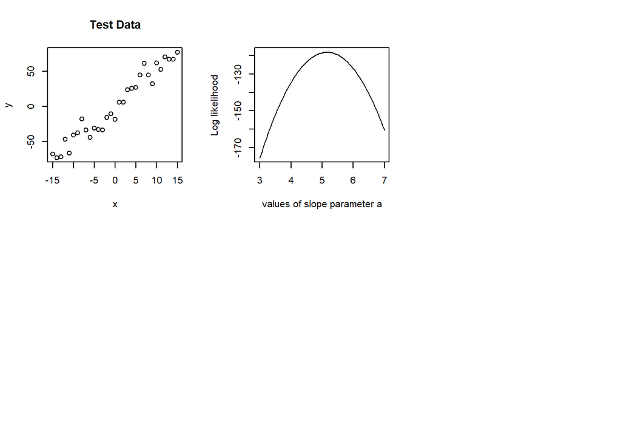

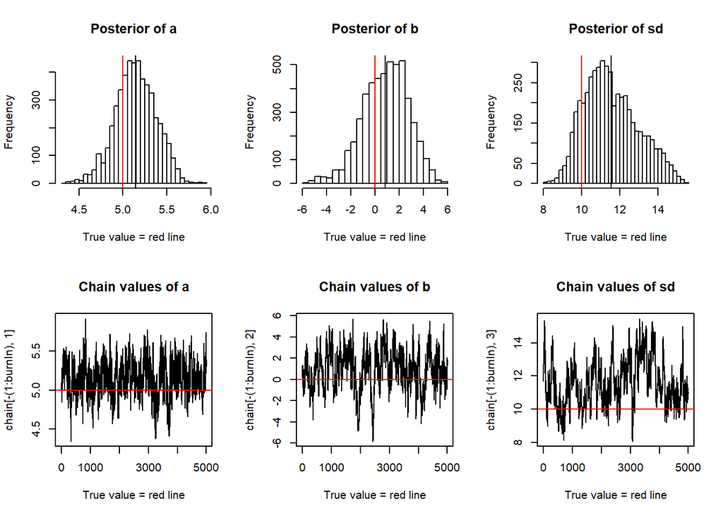

```
##
## Call:
## lm(formula = y ~ x)
##
## Residuals:
##      Min       1Q   Median       3Q      Max
## -18.9733  -6.1717  -0.4887   7.9874  24.4828
##
## Coefficients:
##             Estimate Std. Error t value Pr(>|t|)
## (Intercept)   0.8711     2.0064   0.434    0.667
## x             5.1533     0.2243  22.973   <2e-16 ***
## ---
## Signif. codes:  0 '***' 0.001 '**' 0.01 '*' 0.05 '.' 0.1 ' ' 1
##
## Residual standard error: 11.17 on 29 degrees of freedom
## Multiple R-squared:  0.9479, Adjusted R-squared:  0.9461
## F-statistic: 527.8 on 1 and 29 DF,  p-value: < 2.2e-16
##
## [1] 5.1642654 0.2278266
```

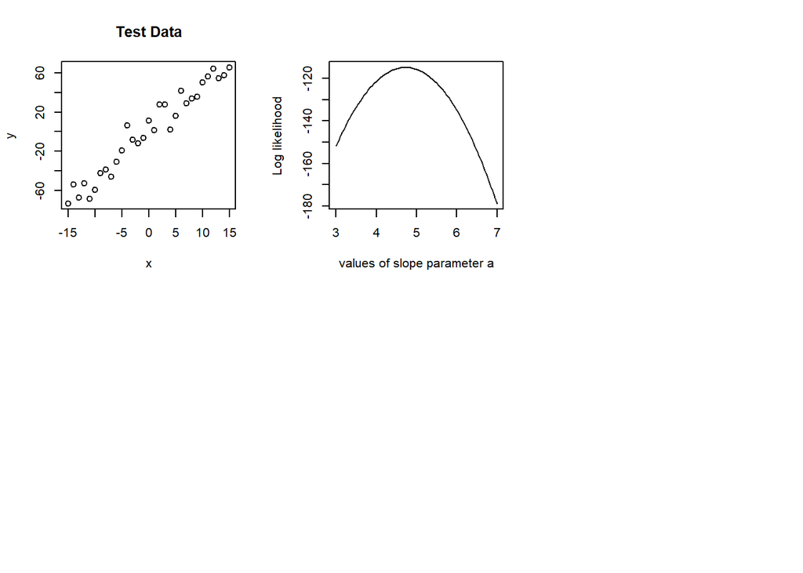

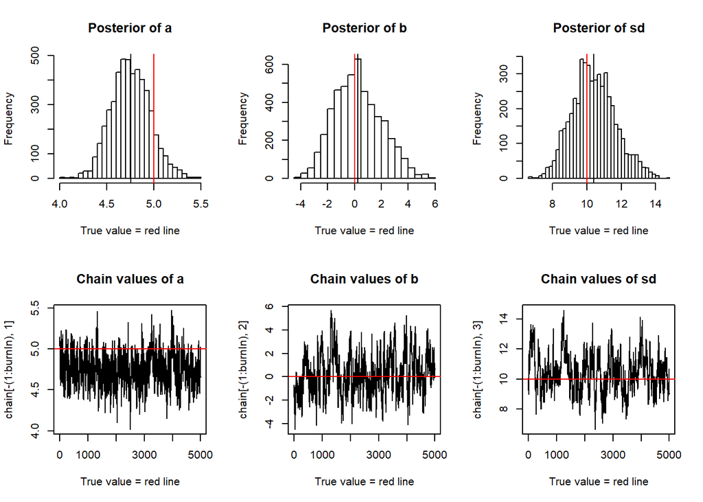

```
##
## Call:
## lm(formula = y ~ x)
##
## Residuals:
##     Min      1Q  Median      3Q     Max
## -16.633  -6.420  -2.485   5.086  25.064
##
## Coefficients:
##             Estimate Std. Error t value Pr(>|t|)
## (Intercept) -0.02151    1.82204  -0.012    0.991
## x            4.72640    0.20371  23.202   <2e-16 ***
## ---
## Signif. codes:  0 '***' 0.001 '**' 0.01 '*' 0.05 '.' 0.1 ' ' 1
##
## Residual standard error: 10.14 on 29 degrees of freedom
## Multiple R-squared:  0.9489, Adjusted R-squared:  0.9471
## F-statistic: 538.3 on 1 and 29 DF,  p-value: < 2.2e-16
##
## [1] 4.7286722 0.2107877
```

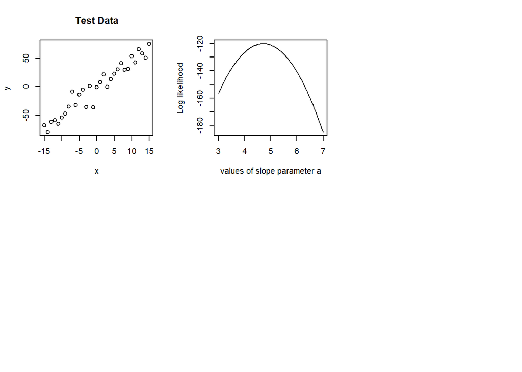

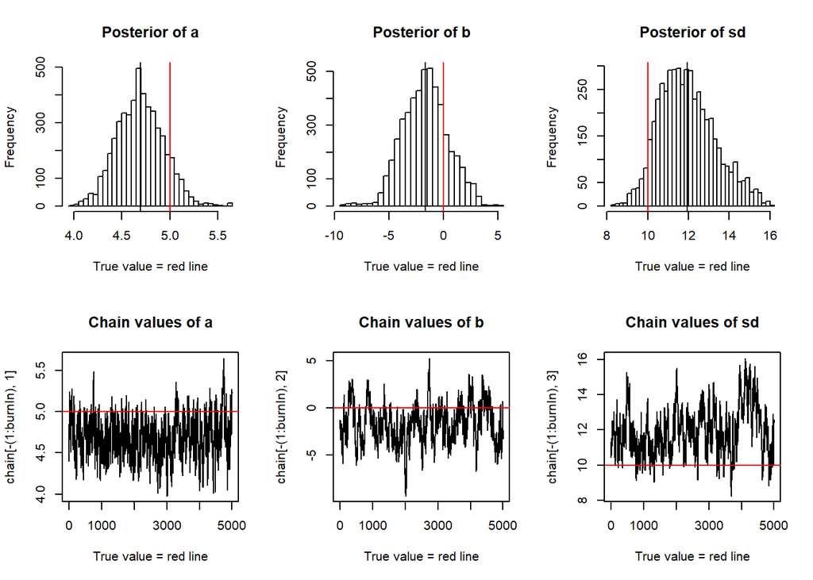

```
##
## Call:
## lm(formula = y ~ x)
##
## Residuals:
##     Min      1Q  Median      3Q     Max
## -29.602  -6.759   1.041   7.445  26.128
##
## Coefficients:
##             Estimate Std. Error t value Pr(>|t|)
## (Intercept)  -1.9611     2.0911  -0.938    0.356
## x             4.7112     0.2338  20.151   <2e-16 ***
## ---
## Signif. codes:  0 '***' 0.001 '**' 0.01 '*' 0.05 '.' 0.1 ' ' 1
##
## Residual standard error: 11.64 on 29 degrees of freedom
## Multiple R-squared:  0.9333, Adjusted R-squared:  0.931
## F-statistic: 406.1 on 1 and 29 DF,  p-value: < 2.2e-16
##
## [1] 4.6987143 0.2533323
```

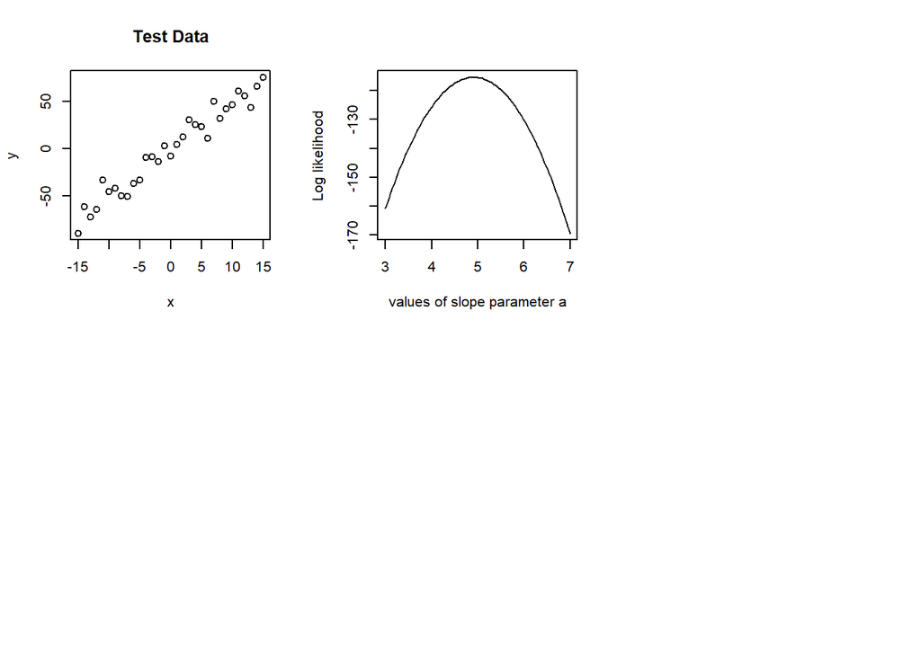

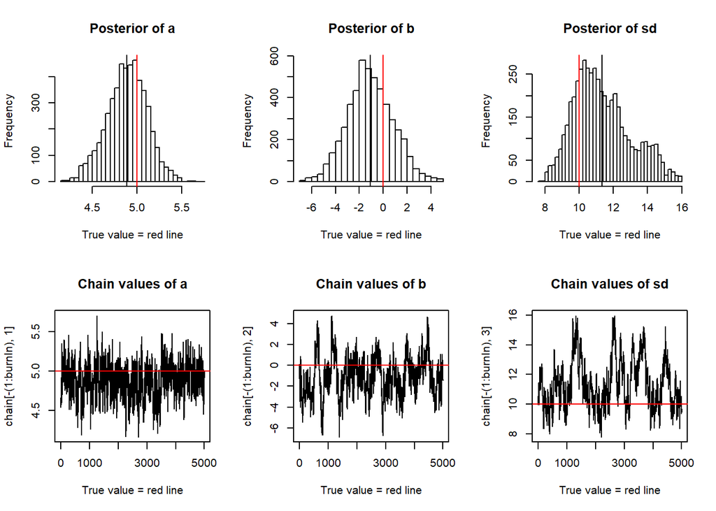

```
##
## Call:
## lm(formula = y ~ x)
##
## Residuals:
##     Min      1Q  Median      3Q     Max
## -19.055  -6.678  -1.065   6.842  21.763
##
## Coefficients:
##             Estimate Std. Error t value Pr(>|t|)
## (Intercept)  -1.4372     1.8363  -0.783     0.44
## x             4.9108     0.2053  23.920   <2e-16 ***
## ---
## Signif. codes:  0 '***' 0.001 '**' 0.01 '*' 0.05 '.' 0.1 ' ' 1
##
## Residual standard error: 10.22 on 29 degrees of freedom
## Multiple R-squared:  0.9518, Adjusted R-squared:  0.9501
## F-statistic: 572.1 on 1 and 29 DF,  p-value: < 2.2e-16
##
## [1] 4.8831428 0.2264185
```

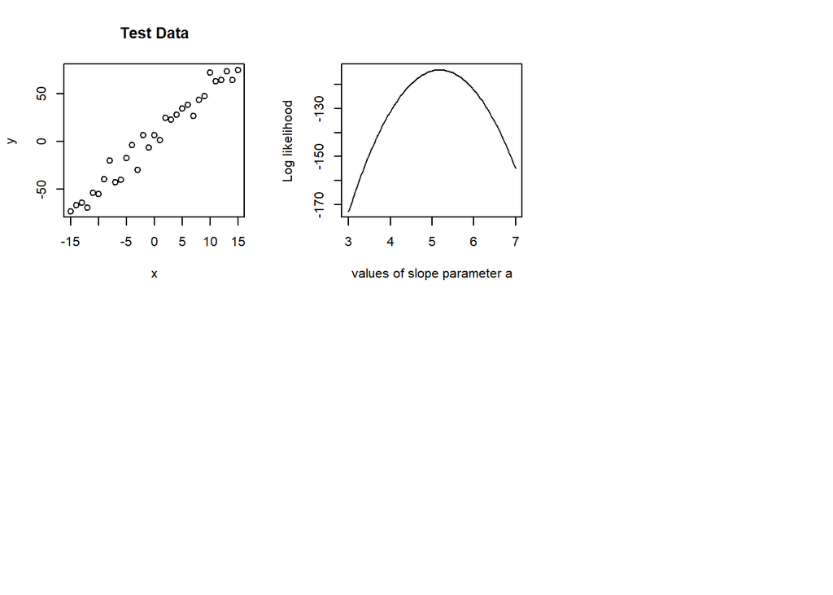

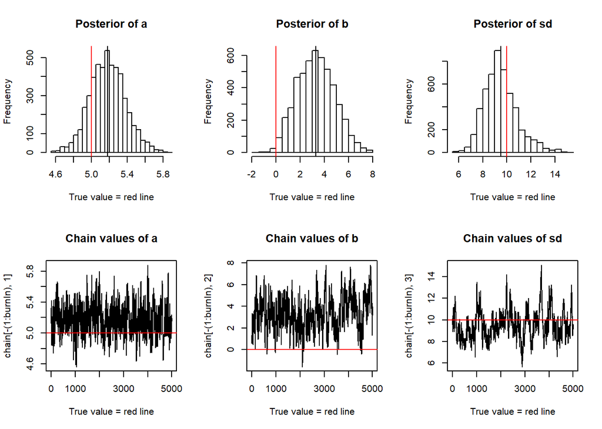

```
##
## Call:
## lm(formula = y ~ x)
##
## Residuals:
##      Min       1Q   Median       3Q      Max
## -17.8778  -6.3868   0.7674   3.5876  18.1155
##
## Coefficients:
##             Estimate Std. Error t value Pr(>|t|)
## (Intercept)   3.6573     1.6304   2.243   0.0327 *
## x             5.1819     0.1823  28.427   <2e-16 ***
## ---
## Signif. codes:  0 '***' 0.001 '**' 0.01 '*' 0.05 '.' 0.1 ' ' 1
##
## Residual standard error: 9.078 on 29 degrees of freedom
## Multiple R-squared:  0.9654, Adjusted R-squared:  0.9642
## F-statistic: 808.1 on 1 and 29 DF,  p-value: < 2.2e-16
##
## [1] 5.1777106 0.2084731
```

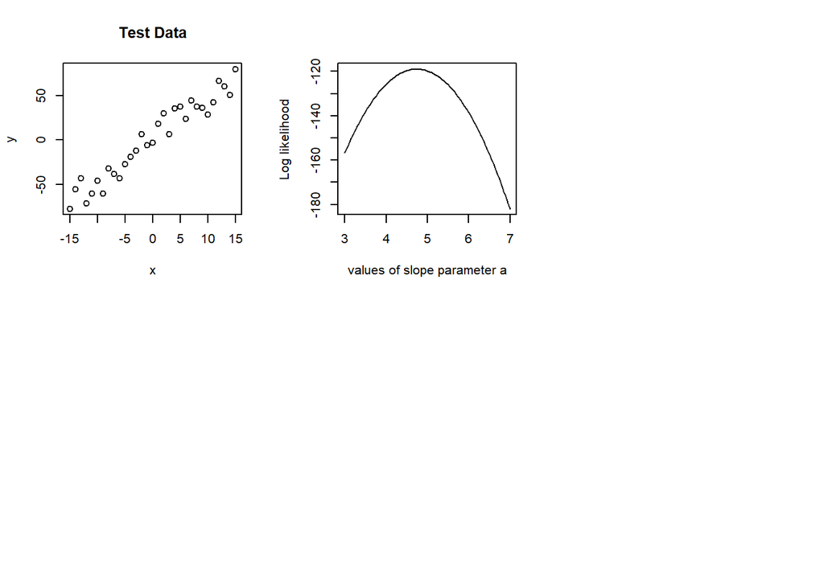

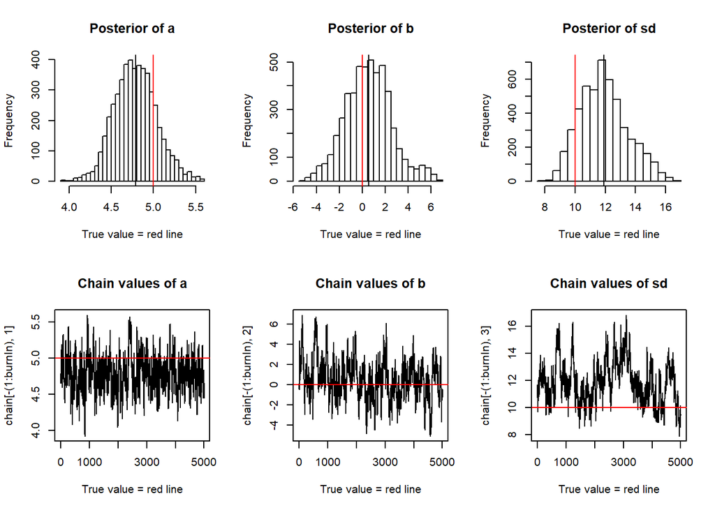

```
##
## Call:
## lm(formula = y ~ x)
##
## Residuals:
##     Min      1Q  Median      3Q     Max
## -19.244  -7.537  -1.484   9.878  19.761
##
## Coefficients:
##             Estimate Std. Error t value Pr(>|t|)
## (Intercept)   0.3878     2.0586   0.188    0.852
## x             4.7433     0.2302  20.608   <2e-16 ***
## ---
## Signif. codes:  0 '***' 0.001 '**' 0.01 '*' 0.05 '.' 0.1 ' ' 1
##
## Residual standard error: 11.46 on 29 degrees of freedom
## Multiple R-squared:  0.9361, Adjusted R-squared:  0.9339
## F-statistic: 424.7 on 1 and 29 DF,  p-value: < 2.2e-16
##
## [1] 4.7659297 0.2442234
```

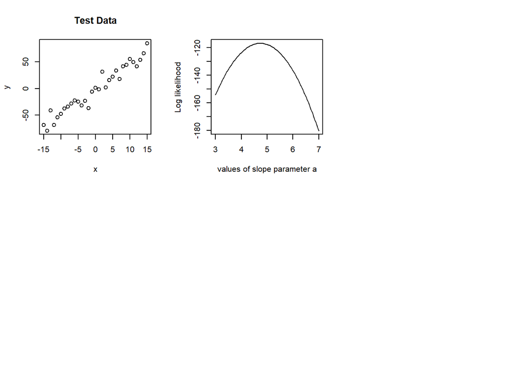

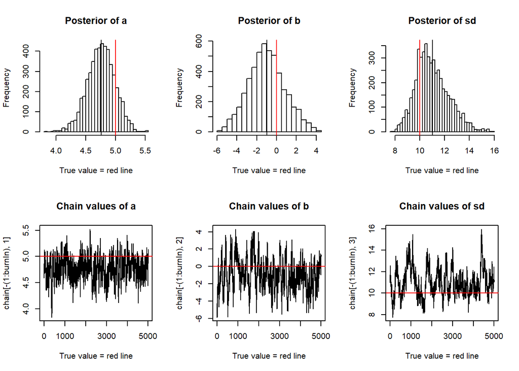

```
##
## Call:
## lm(formula = y ~ x)
##
## Residuals:
##      Min       1Q   Median       3Q      Max
## -25.8302  -6.7136   0.4478   5.6980  23.1738
##
## Coefficients:
##             Estimate Std. Error t value Pr(>|t|)
## (Intercept)   -1.529      1.914  -0.799    0.431
## x              4.736      0.214  22.134   <2e-16 ***
## ---
## Signif. codes:  0 '***' 0.001 '**' 0.01 '*' 0.05 '.' 0.1 ' ' 1
##
## Residual standard error: 10.66 on 29 degrees of freedom
## Multiple R-squared:  0.9441, Adjusted R-squared:  0.9422
## F-statistic: 489.9 on 1 and 29 DF,  p-value: < 2.2e-16
##
## [1] 4.7502582 0.2267782
```

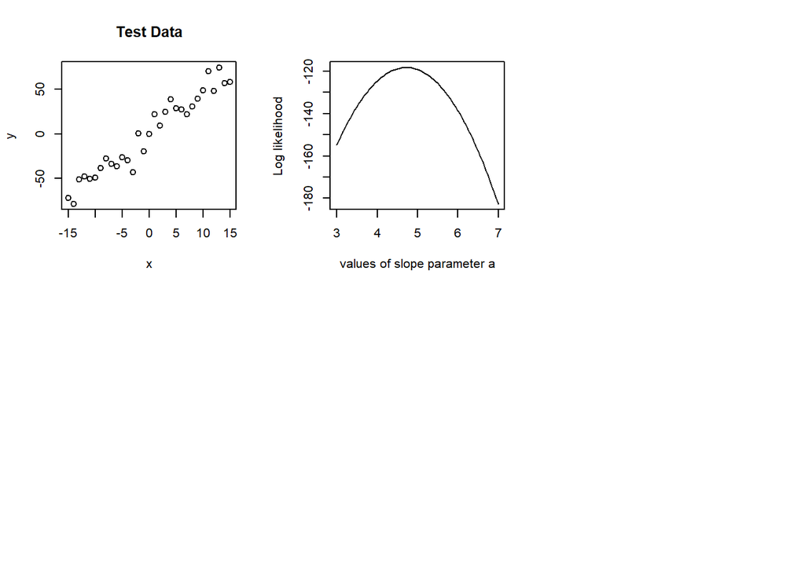

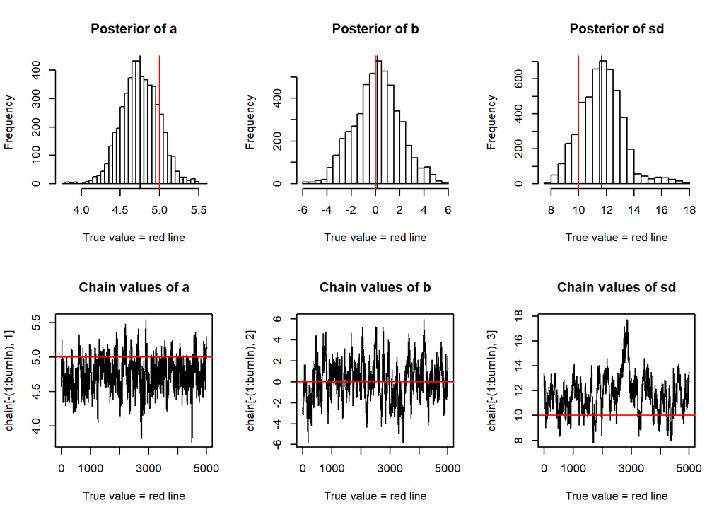

```
##
## Call:
## lm(formula = y ~ x)
##
## Residuals:
##      Min       1Q   Median       3Q      Max
## -29.0751  -7.8630  -0.7471   9.6423  20.2453
##
## Coefficients:
##             Estimate Std. Error t value Pr(>|t|)
## (Intercept)  -0.3250     2.0153  -0.161    0.873
## x             4.7171     0.2253  20.936   <2e-16 ***
## ---
## Signif. codes:  0 '***' 0.001 '**' 0.01 '*' 0.05 '.' 0.1 ' ' 1
##
## Residual standard error: 11.22 on 29 degrees of freedom
## Multiple R-squared:  0.9379, Adjusted R-squared:  0.9358
## F-statistic: 438.3 on 1 and 29 DF,  p-value: < 2.2e-16
##
## [1] 4.7223000 0.2425869
```

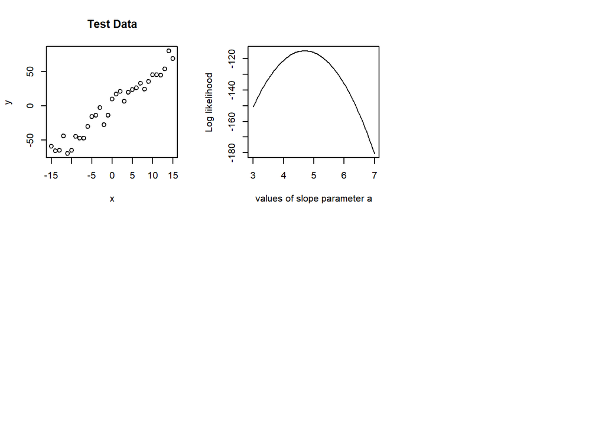

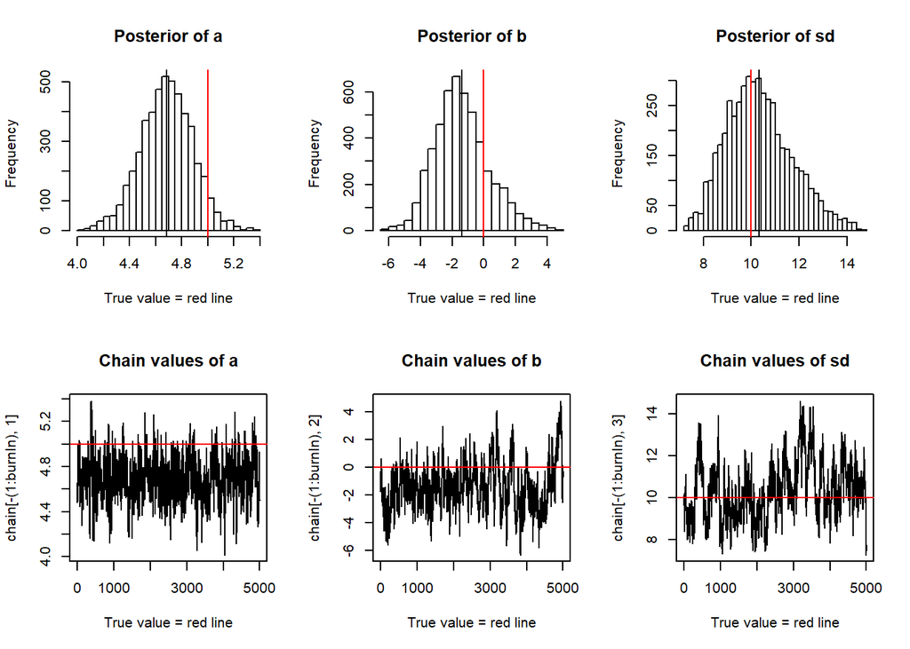

```
##
## Call:
## lm(formula = y ~ x)
##
## Residuals:
##      Min       1Q   Median       3Q      Max
## -16.5557  -6.5128  -0.1769   8.1796  16.6901
##
## Coefficients:
##             Estimate Std. Error t value Pr(>|t|)
## (Intercept)  -1.8467     1.7964  -1.028    0.312
## x             4.6998     0.2008  23.401   <2e-16 ***
## ---
## Signif. codes:  0 '***' 0.001 '**' 0.01 '*' 0.05 '.' 0.1 ' ' 1
##
## Residual standard error: 10 on 29 degrees of freedom
## Multiple R-squared:  0.9497, Adjusted R-squared:  0.948
## F-statistic: 547.6 on 1 and 29 DF,  p-value: < 2.2e-16
##
## [1] 4.6921181 0.2125435
```

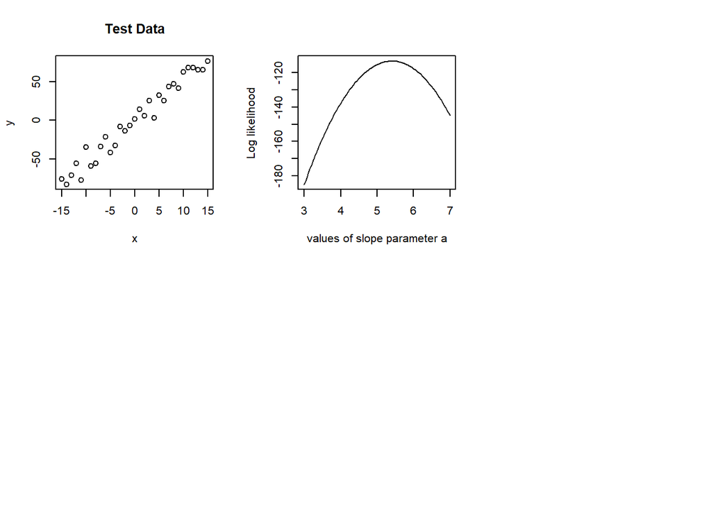

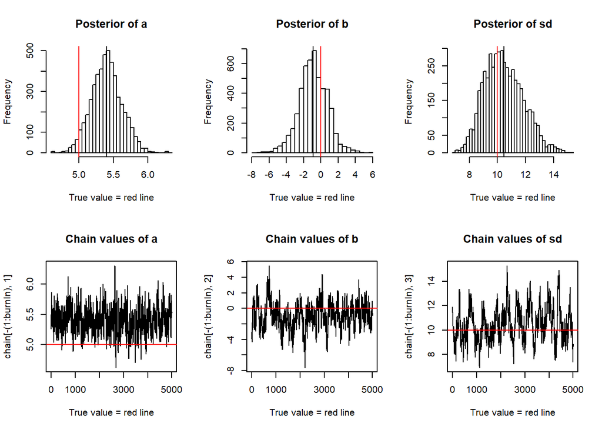

```
##
## Call:
## lm(formula = y ~ x)
##
## Residuals:
##      Min       1Q   Median       3Q      Max
## -17.8031  -6.4597   0.1045   7.6771  20.3682
##
## Coefficients:
##             Estimate Std. Error t value Pr(>|t|)
## (Intercept)  -0.8979     1.7177  -0.523    0.605
## x             5.4053     0.1921  28.145   <2e-16 ***
## ---
## Signif. codes:  0 '***' 0.001 '**' 0.01 '*' 0.05 '.' 0.1 ' ' 1
##
## Residual standard error: 9.564 on 29 degrees of freedom
## Multiple R-squared:  0.9647, Adjusted R-squared:  0.9635
## F-statistic: 792.2 on 1 and 29 DF,  p-value: < 2.2e-16
##
## [1] 5.4090532 0.2192166
```

```r
  names2 <- c("slope 10000", "intercept 10000")
  final2 <- rbind(names2,a_vals2)


print("*****************************************************************")
```

```
## [1] "*****************************************************************"
```

```r
print("100000 iterations, 50000 burnIn")
```

```
## [1] "100000 iterations, 50000 burnIn"
```

```r
  a_vals2 <- compare_outcomes(100000, 50000)
```

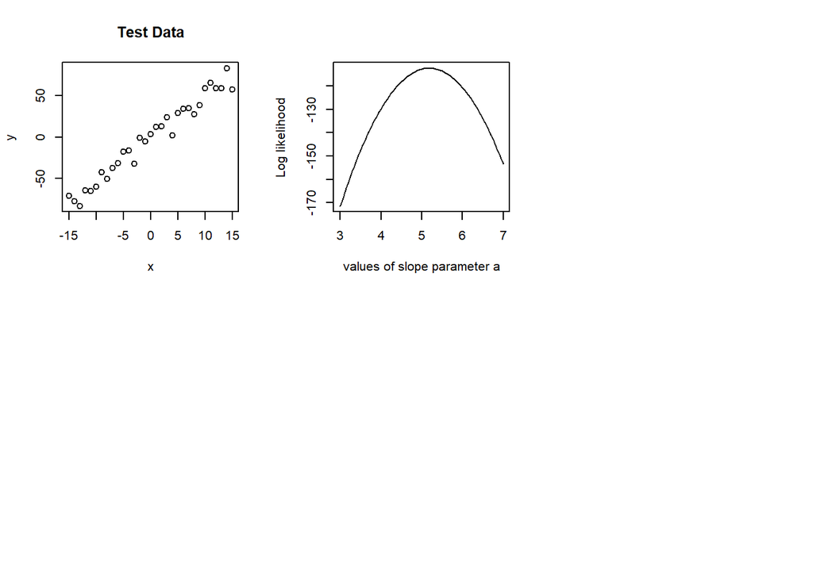

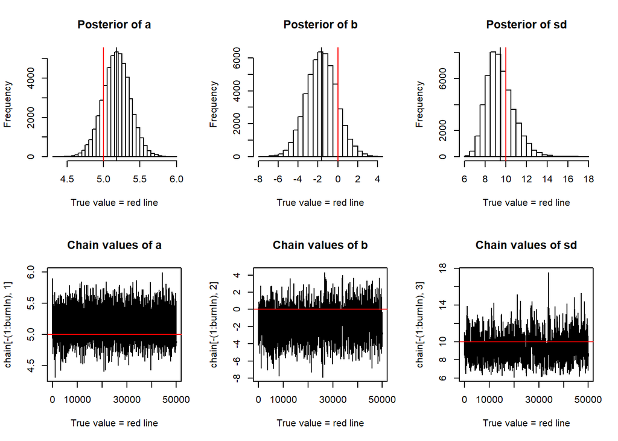

```
##
## Call:
## lm(formula = y ~ x)
##
## Residuals:
##     Min      1Q  Median      3Q     Max
## -19.027  -6.361   1.327   7.391  12.129
##
## Coefficients:
##             Estimate Std. Error t value Pr(>|t|)
## (Intercept)  -1.8844     1.6328  -1.154    0.258
## x             5.1835     0.1826  28.395   <2e-16 ***
## ---
## Signif. codes:  0 '***' 0.001 '**' 0.01 '*' 0.05 '.' 0.1 ' ' 1
##
## Residual standard error: 9.091 on 29 degrees of freedom
## Multiple R-squared:  0.9653, Adjusted R-squared:  0.9641
## F-statistic: 806.2 on 1 and 29 DF,  p-value: < 2.2e-16
##
## [1] 5.1821166 0.1926388
```

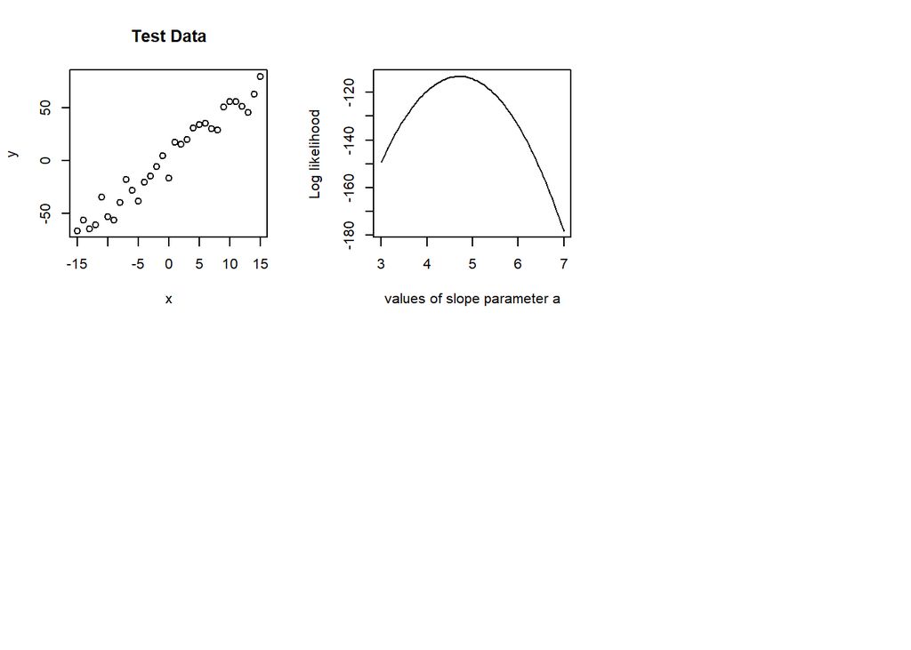

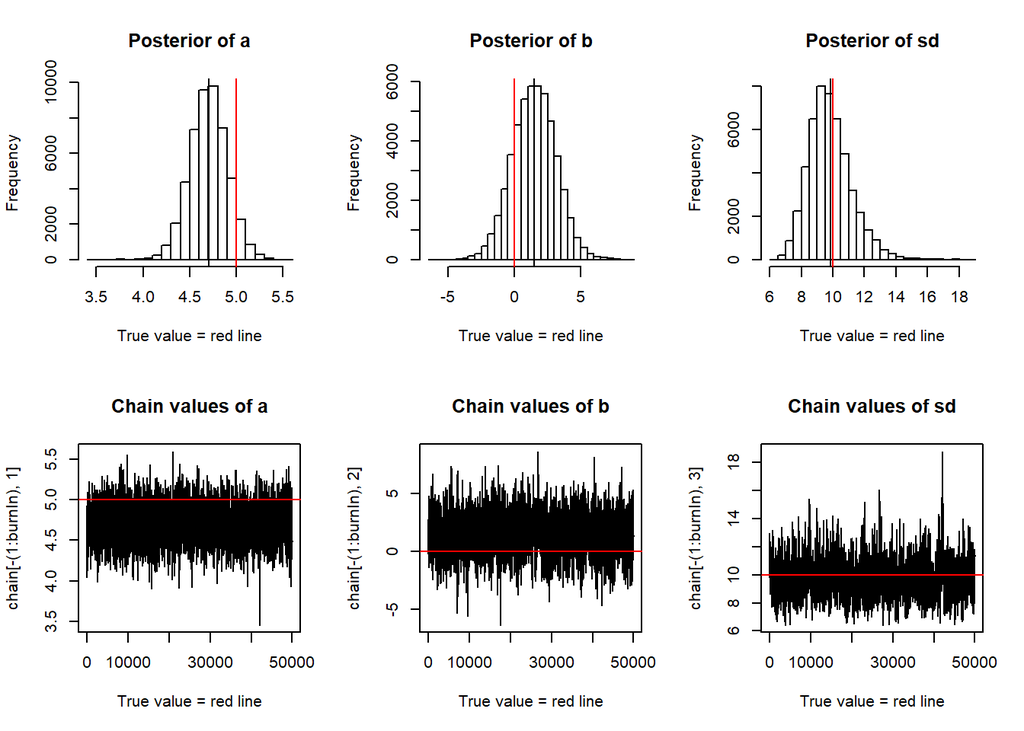

```
##
## Call:
## lm(formula = y ~ x)
##
## Residuals:
##     Min      1Q  Median      3Q     Max
## -17.750  -5.341   2.036   7.422  15.808
##
## Coefficients:
##             Estimate Std. Error t value Pr(>|t|)
## (Intercept)   1.6576     1.6930   0.979    0.336
## x             4.7060     0.1893  24.862   <2e-16 ***
## ---
## Signif. codes:  0 '***' 0.001 '**' 0.01 '*' 0.05 '.' 0.1 ' ' 1
##
## Residual standard error: 9.426 on 29 degrees of freedom
## Multiple R-squared:  0.9552, Adjusted R-squared:  0.9536
## F-statistic: 618.1 on 1 and 29 DF,  p-value: < 2.2e-16
##
## [1] 4.7004414 0.2054475
```

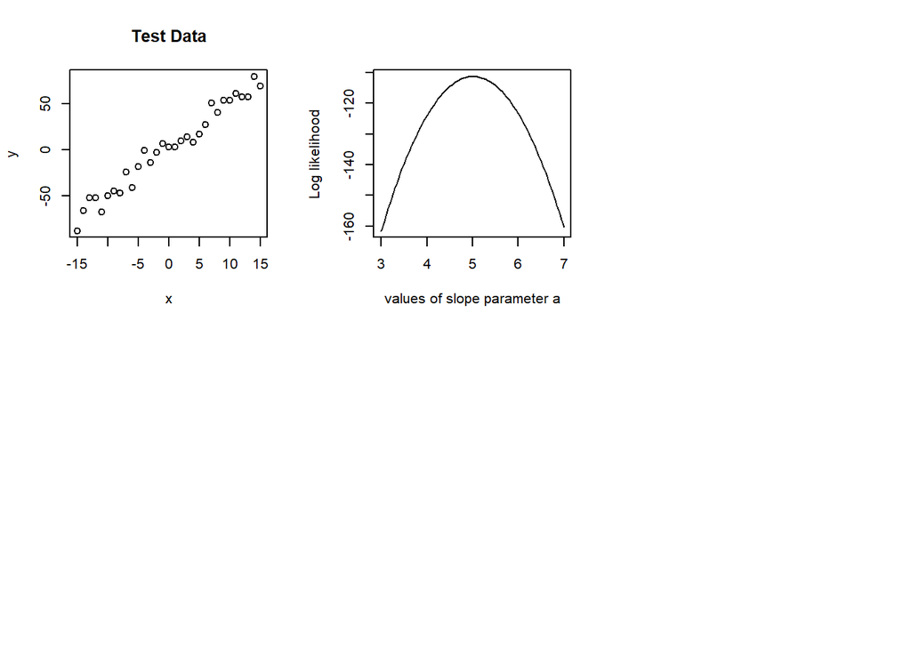

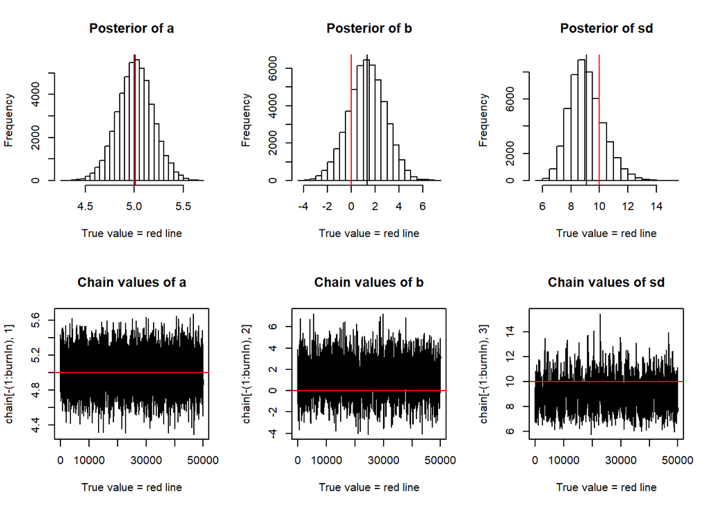

```
##
## Call:
## lm(formula = y ~ x)
##
## Residuals:
##      Min       1Q   Median       3Q      Max
## -14.4361  -5.6357  -0.7523   6.1096  18.0976
##
## Coefficients:
##             Estimate Std. Error t value Pr(>|t|)
## (Intercept)   1.4524     1.5718   0.924    0.363
## x             5.0136     0.1757  28.529   <2e-16 ***
## ---
## Signif. codes:  0 '***' 0.001 '**' 0.01 '*' 0.05 '.' 0.1 ' ' 1
##
## Residual standard error: 8.752 on 29 degrees of freedom
## Multiple R-squared:  0.9656, Adjusted R-squared:  0.9644
## F-statistic: 813.9 on 1 and 29 DF,  p-value: < 2.2e-16
##
## [1] 5.0102543 0.1839108
```

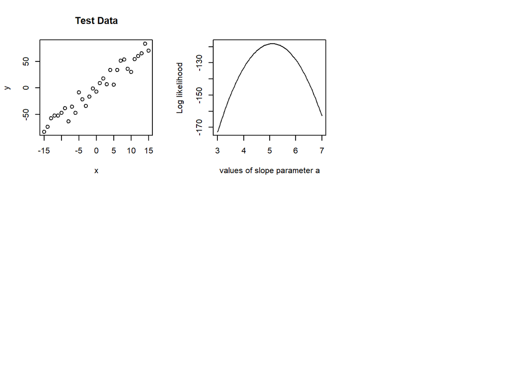

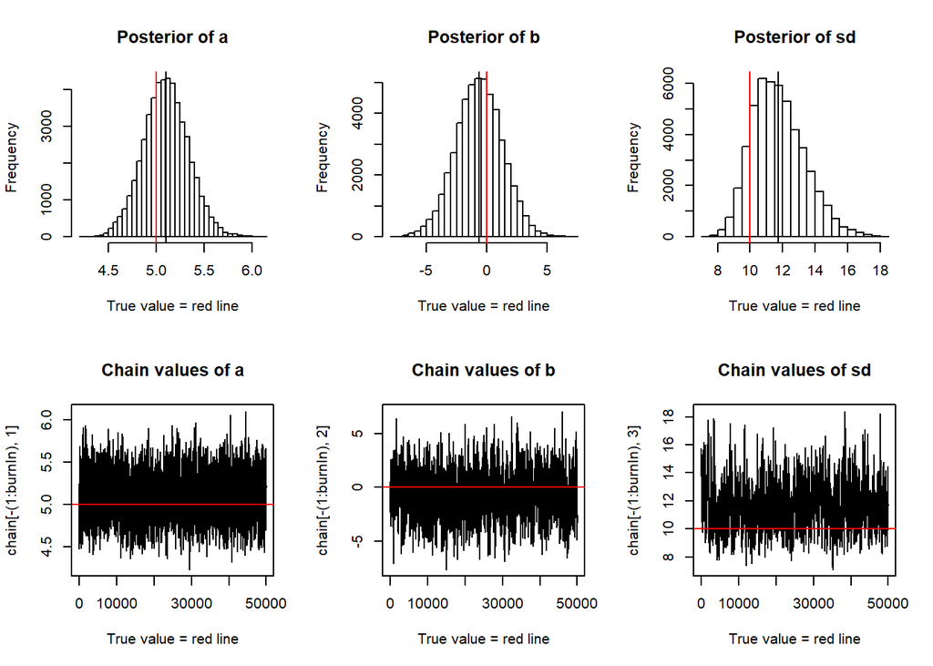

```
##
## Call:
## lm(formula = y ~ x)
##
## Residuals:
##      Min       1Q   Median       3Q      Max
## -21.7201  -5.9546   0.2595   8.3647  17.5222
##
## Coefficients:
##             Estimate Std. Error t value Pr(>|t|)
## (Intercept)  -0.8706     2.0044  -0.434    0.667
## x             5.1013     0.2241  22.763   <2e-16 ***
## ---
## Signif. codes:  0 '***' 0.001 '**' 0.01 '*' 0.05 '.' 0.1 ' ' 1
##
## Residual standard error: 11.16 on 29 degrees of freedom
## Multiple R-squared:  0.947,  Adjusted R-squared:  0.9452
## F-statistic: 518.2 on 1 and 29 DF,  p-value: < 2.2e-16
##
## [1] 5.1026799 0.2385284
```

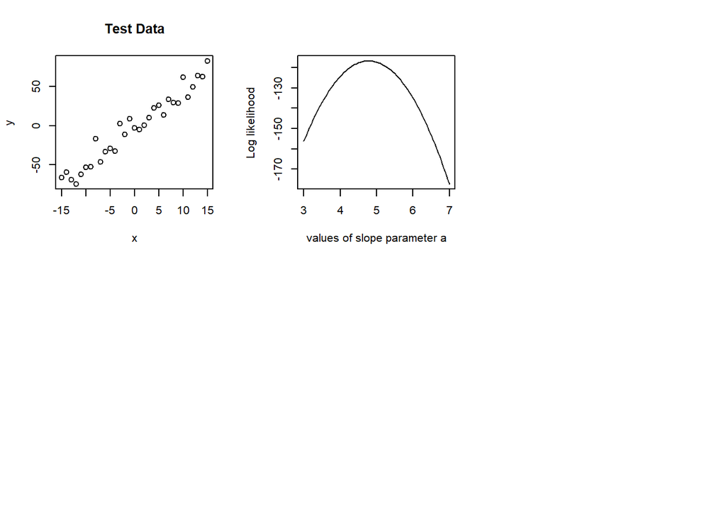

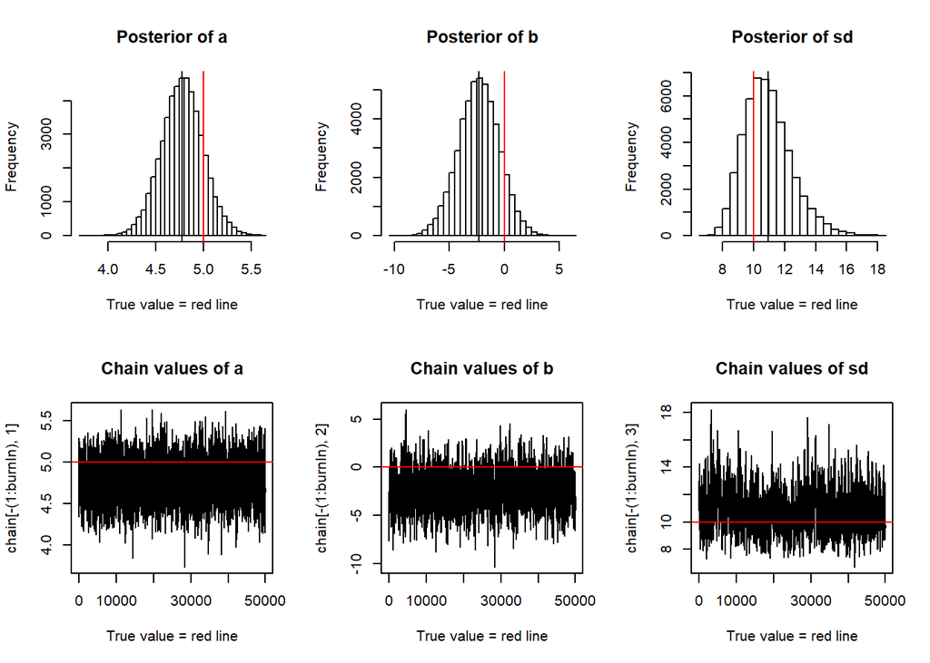

```
##
## Call:
## lm(formula = y ~ x)
##
## Residuals:
##     Min      1Q  Median      3Q     Max
## -14.552  -6.817  -1.651   5.413  23.958
##
## Coefficients:
##             Estimate Std. Error t value Pr(>|t|)
## (Intercept)  -2.6230     1.8667  -1.405    0.171
## x             4.7848     0.2087  22.927   <2e-16 ***
## ---
## Signif. codes:  0 '***' 0.001 '**' 0.01 '*' 0.05 '.' 0.1 ' ' 1
##
## Residual standard error: 10.39 on 29 degrees of freedom
## Multiple R-squared:  0.9477, Adjusted R-squared:  0.9459
## F-statistic: 525.6 on 1 and 29 DF,  p-value: < 2.2e-16
##
## [1] 4.7850848 0.2224905
```

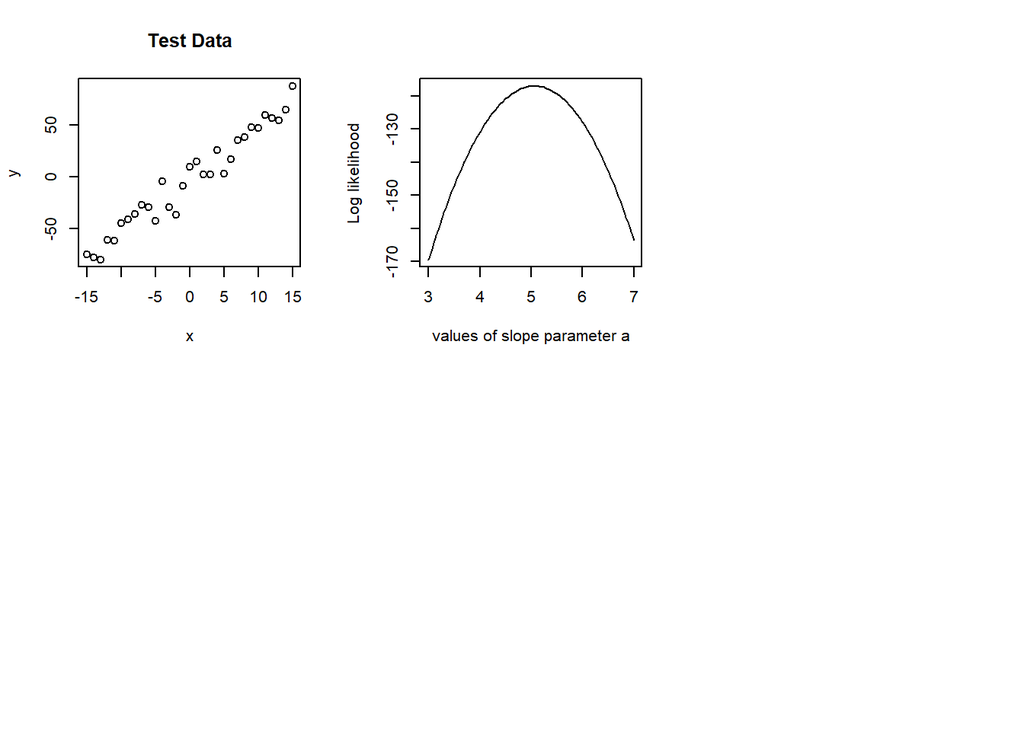

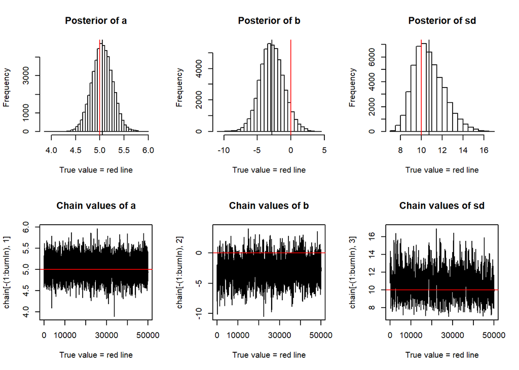

```
##
## Call:
## lm(formula = y ~ x)
##
## Residuals:
##     Min      1Q  Median      3Q     Max
## -23.576  -6.751   1.010   7.206  18.687
##
## Coefficients:
##             Estimate Std. Error t value Pr(>|t|)
## (Intercept)  -3.1199     1.8586  -1.679    0.104
## x             5.0612     0.2078  24.357   <2e-16 ***
## ---
## Signif. codes:  0 '***' 0.001 '**' 0.01 '*' 0.05 '.' 0.1 ' ' 1
##
## Residual standard error: 10.35 on 29 degrees of freedom
## Multiple R-squared:  0.9534, Adjusted R-squared:  0.9518
## F-statistic: 593.2 on 1 and 29 DF,  p-value: < 2.2e-16
##
## [1] 5.0568437 0.2181655
```

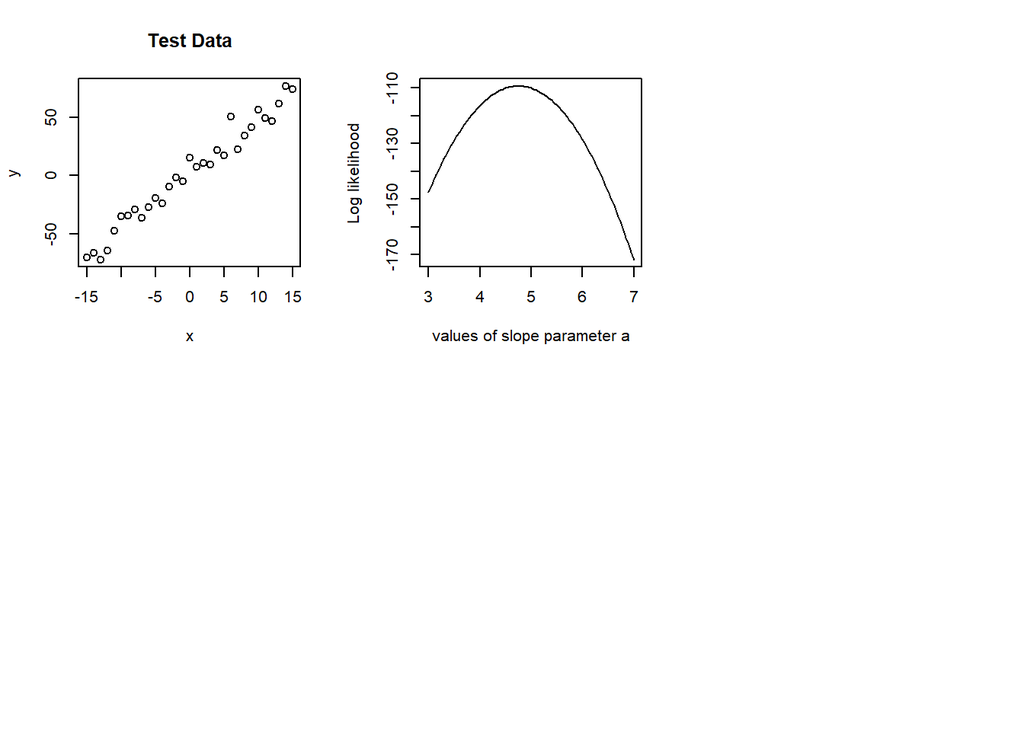

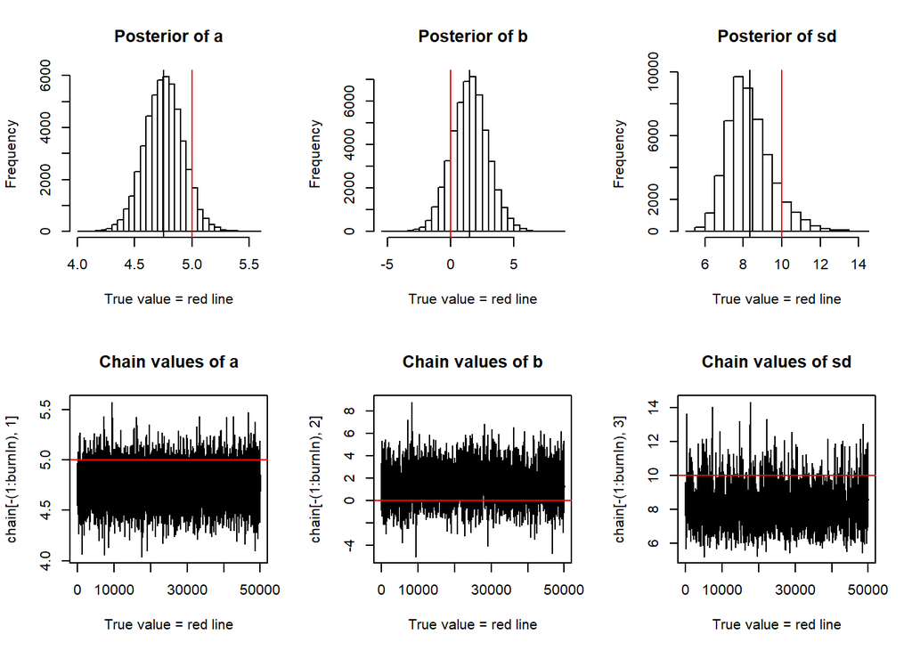

```
##
## Call:
## lm(formula = y ~ x)
##
## Residuals:
##      Min       1Q   Median       3Q      Max
## -12.6511  -5.2897  -0.6612   4.5633  20.4835
##
## Coefficients:
##             Estimate Std. Error t value Pr(>|t|)
## (Intercept)   1.6559     1.4166   1.169    0.252
## x             4.7539     0.1584  30.016   <2e-16 ***
## ---
## Signif. codes:  0 '***' 0.001 '**' 0.01 '*' 0.05 '.' 0.1 ' ' 1
##
## Residual standard error: 7.887 on 29 degrees of freedom
## Multiple R-squared:  0.9688, Adjusted R-squared:  0.9677
## F-statistic:   901 on 1 and 29 DF,  p-value: < 2.2e-16
##
## [1] 4.7525616 0.1668038
```

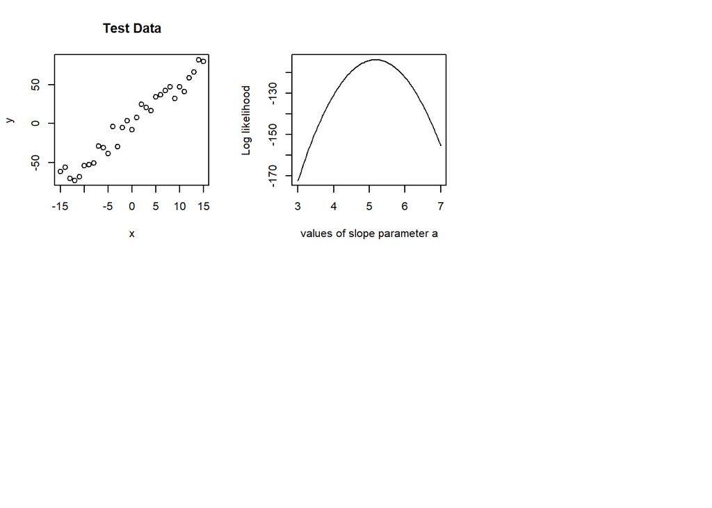

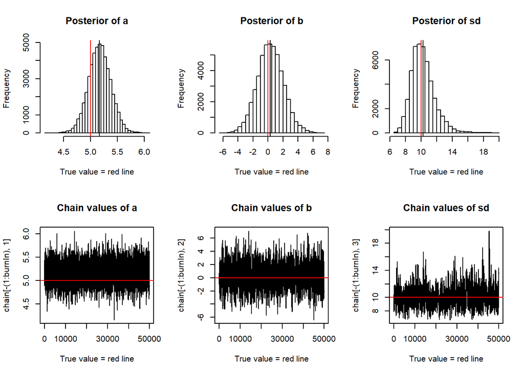

```
##
## Call:
## lm(formula = y ~ x)
##
## Residuals:
##      Min       1Q   Median       3Q      Max
## -15.9234  -7.6109  -0.7543   6.5282  16.1276
##
## Coefficients:
##             Estimate Std. Error t value Pr(>|t|)
## (Intercept)   0.4312     1.7623   0.245    0.808
## x             5.1703     0.1970  26.241   <2e-16 ***
## ---
## Signif. codes:  0 '***' 0.001 '**' 0.01 '*' 0.05 '.' 0.1 ' ' 1
##
## Residual standard error: 9.812 on 29 degrees of freedom
## Multiple R-squared:  0.9596, Adjusted R-squared:  0.9582
## F-statistic: 688.6 on 1 and 29 DF,  p-value: < 2.2e-16
##
## [1] 5.1763000 0.2089168
```

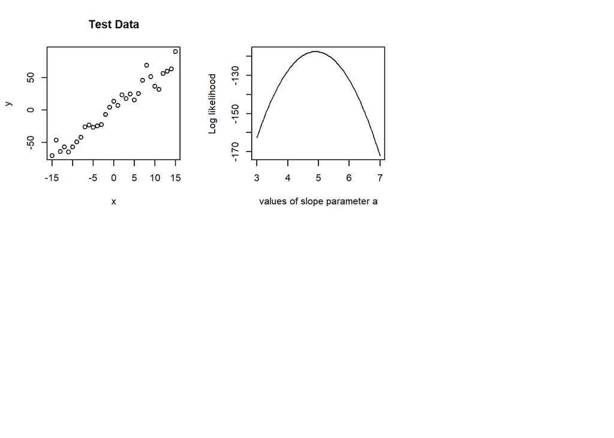

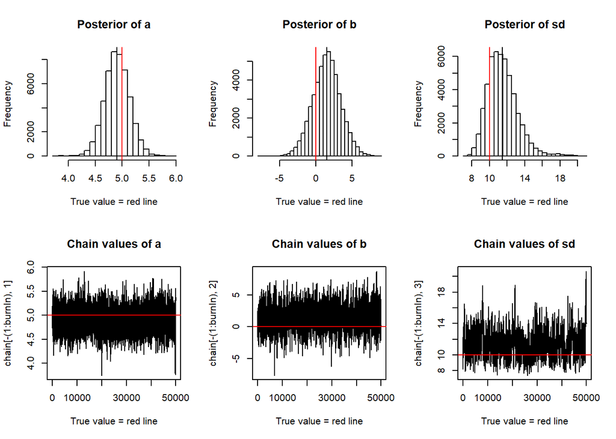

```
##
## Call:
## lm(formula = y ~ x)
##
## Residuals:
##      Min       1Q   Median       3Q      Max
## -23.7222  -6.7234  -0.2572   6.0549  28.2502
##
## Coefficients:
##             Estimate Std. Error t value Pr(>|t|)
## (Intercept)   1.6632     1.9600   0.849    0.403
## x             4.9032     0.2191  22.375   <2e-16 ***
## ---
## Signif. codes:  0 '***' 0.001 '**' 0.01 '*' 0.05 '.' 0.1 ' ' 1
##
## Residual standard error: 10.91 on 29 degrees of freedom
## Multiple R-squared:  0.9452, Adjusted R-squared:  0.9434
## F-statistic: 500.7 on 1 and 29 DF,  p-value: < 2.2e-16
##
## [1] 4.903623 0.234323
```

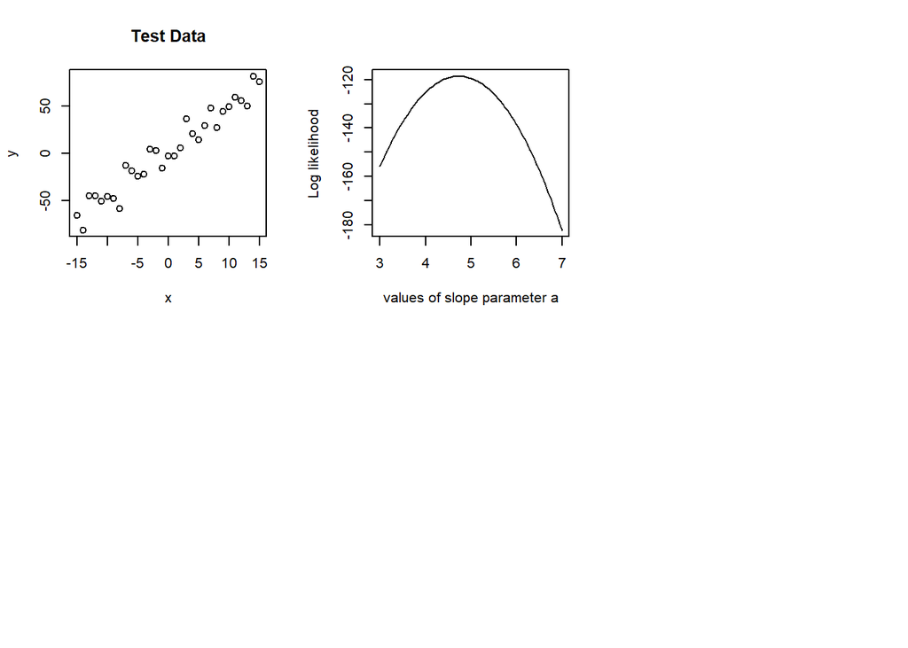

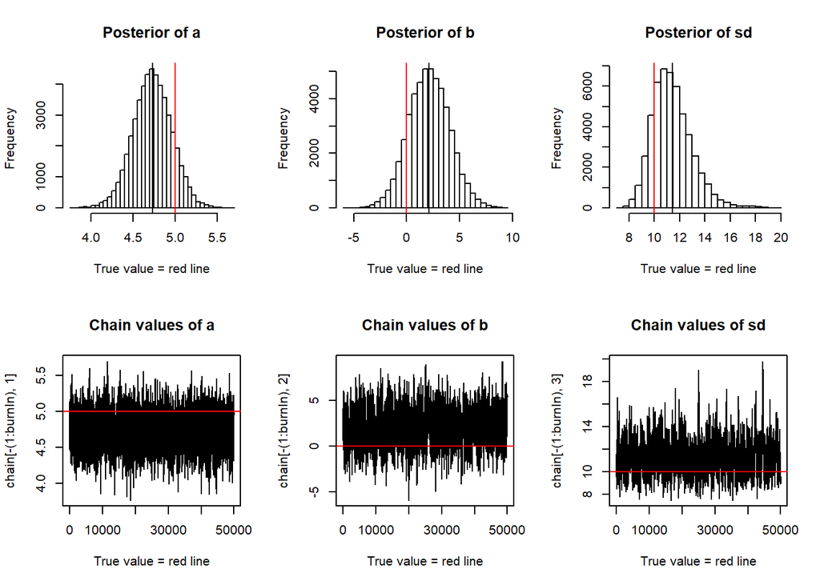

```
##
## Call:
## lm(formula = y ~ x)
##
## Residuals:
##      Min       1Q   Median       3Q      Max
## -22.6438  -6.8518  -0.4844   8.6816  19.9597
##
## Coefficients:
##             Estimate Std. Error t value Pr(>|t|)
## (Intercept)   2.4139     1.9891   1.214    0.235
## x             4.7324     0.2224  21.280   <2e-16 ***
## ---
## Signif. codes:  0 '***' 0.001 '**' 0.01 '*' 0.05 '.' 0.1 ' ' 1
##
## Residual standard error: 11.07 on 29 degrees of freedom
## Multiple R-squared:  0.9398, Adjusted R-squared:  0.9377
## F-statistic: 452.8 on 1 and 29 DF,  p-value: < 2.2e-16
##
## [1] 4.7300884 0.2331122
```

```r
names3 <- c("slope 100000", "intercept 100000")
  final3 <- rbind(names3,a_vals2)

print(final)
```

```
##       [,1]               [,2]
## names "slope 1000"       "intercept 1000"
##       "4.81833081760428" "0.219894656906717"
##       "4.8547159366171"  "0.167686113914558"
##       "5.04866839214756" "0.293392184755118"
##       "4.84663938321036" "0.245369721323029"
##       "4.95792534318301" "0.2366213780413"
##       "5.01308418028383" "0.254948020362965"
##       "5.23167335216636" "0.24713820781395"
##       "4.89494663564287" "0.248148170456445"
##       "4.74706101040798" "0.183858092180926"
##       "4.78463304360084" "0.232192050847517"
```

```r
print(final2)
```

```
##        [,1]               [,2]
## names2 "slope 10000"      "intercept 10000"
##        "5.16426544533692" "0.227826561755839"
##        "4.72867221817929" "0.210787700761638"
##        "4.69871430286451" "0.253332334260809"
##        "4.88314281137642" "0.226418497415636"
##        "5.17771064127594" "0.20847310247348"
##        "4.76592971471247" "0.244223377733278"
##        "4.75025823441622" "0.226778245030135"
##        "4.72230002053108" "0.242586894274282"
##        "4.69211809028326" "0.212543529255336"
##        "5.40905324294732" "0.219216602443027"
```

```r
print(final3)
```

```
##        [,1]               [,2]
## names3 "slope 100000"     "intercept 100000"
##        "5.18211663881919" "0.192638844553722"
##        "4.70044140782132" "0.205447515343275"
##        "5.01025426865728" "0.183910823816408"
##        "5.1026798826496"  "0.238528403981398"
##        "4.7850847705294"  "0.222490454686791"
##        "5.05684366118961" "0.218165469060323"
##        "4.75256155473872" "0.166803763167326"
##        "5.17630004681046" "0.20891682637382"
##        "4.903622794649"   "0.234322961275733"
##        "4.7300884038595"  "0.233112237842334"
```

The value of a predicted by the iterations doesn’t converge to the true value but does appear to converge to the Least Squares model with increasing iterations. I do notice that the histogram for a becomes more sharply peaked as well as the fact that the true estimate is bettered centered towards the middle of the plot of chain. This effect is observed as one transitions both between 1000 iterations with 500 burnIn to 10000 iterations with 5000 burnIn, as well as between the latter and 100000 with 50000 burnIn. With higher numbers of iterations we see the values predicted by the Metropolis Hastings begin to converge to those of the standard linear distribution.